# ANOVA test for score

Geiser C. Challco geiser@alumni.usp.br

- ANOVA: score ~ time
  - Data Preparation
  - Summary Statistics
  - ANOVA Computation
  - PairWise Computation
- ANOVA: score ~ time*gender + Error(id/time)
  - Data Preparation
    - Check assumptions: Identifying Outliers
    - Check assumptions: Normality Test
    - Summary Statistics
  - ANOVA Computation
  - ANOVA Computation after removing non.normal data
  - PairWise Computation
  - PairWise Computation after removing non.normal data
- ANOVA: score ~ time*localizacao + Error(id/time)
  - Data Preparation
    - Check assumptions: Identifying Outliers
    - Check assumptions: Normality Test
    - Summary Statistics
  - ANOVA Computation
  - ANOVA Computation after removing non.normal data
  - PairWise Computation
  - PairWise Computation after removing non.normal data
- ANOVA: score ~ time*regiao + Error(id/time)
  - Data Preparation
    - Check assumptions: Identifying Outliers
    - Check assumptions: Normality Test
    - Summary Statistics
  - ANOVA Computation
  - ANOVA Computation after removing non.normal data
  - PairWise Computation
  - PairWise Computation after removing non.normal data
- ANOVA: score ~ time*porte + Error(id/time)
  - Data Preparation
    - Check assumptions: Identifying Outliers
    - Check assumptions: Normality Test
    - Summary Statistics
  - ANOVA Computation
  - ANOVA Computation after removing non.normal data
  - PairWise Computation
  - PairWise Computation after removing non.normal data

```r
dat <- read_excel("../data/data.xlsx", sheet = "alunos_ef59")

escolas <- read_excel("../data/data.xlsx", sheet = "escolas")
edat <- merge(dat, escolas, by = "cod_escola", all.x = T)
```

# ANOVA: score ~ time

## Data Preparation

```r
data <- edat[,c("aluno_id","ciclo","score")]
data <- data[data$ciclo %in% c("Primeiro Ciclo","Terceiro Ciclo"),]
data$ciclo <- factor(data$ciclo, c("Primeiro Ciclo","Terceiro Ciclo"))
data <- unique(data)

wdat <- spread(data, ciclo, score)
wdat <- wdat[complete.cases(wdat),]
colnames(wdat) <- c("id","c1","c3")

ldat <- gather(wdat, key = time, value = score, c1,c3) %>%
  convert_as_factor(id, time)
ldat <- rshinystatistics::remove_group_data(ldat, "score", "time", n.limit = 30)
```

## Summary Statistics

```r
(sdat <- ldat %>% group_by(time) %>%
   get_summary_stats(score, type = "mean_sd"))
```

```
## # A tibble: 2 × 5
##   time  variable     n  mean    sd
##   <fct> <fct>    <dbl> <dbl> <dbl>
## 1 c1    score     3997  1.77 0.304
## 2 c3    score     3997  1.73 0.315
```

| time | variable | n | mean | sd |
| --- | --- | --- | --- | --- |
| c1 | score | 3997 | 1.772 | 0.304 |
| c3 | score | 3997 | 1.729 | 0.315 |

## ANOVA Computation

```r
(res.aov <- anova_test(ldat, dv = score, wid = id, within = time))
```

```
## ANOVA Table (type III tests)
##
##   Effect DFn  DFd      F        p p<.05   ges
## 1   time   1 3996 44.379 3.07e-11     * 0.005
```

## PairWise Computation

```r
(pwc <- ldat %>% emmeans_test(score ~ time, detailed = T, p.adjust.method = "bonferroni"))
```

```
## # A tibble: 1 × 14
##   term  .y.   group1 group2 null.value estimate      se    df conf.low conf.high
## * <chr> <chr> <chr>  <chr>       <dbl>    <dbl>   <dbl> <dbl>    <dbl>     <dbl>
## 1 time  score c1     c3              0   0.0433 0.00693  7992   0.0297    0.0568
## # ℹ 4 more variables: statistic <dbl>, p <dbl>, p.adj <dbl>, p.adj.signif <chr>
```

| term | .y. | group1 | group2 | null.value | estimate | se | df | conf.low | conf.high | statistic | p | p.adj | p.adj.signif |
| --- | --- | --- | --- | --- | --- | --- | --- | --- | --- | --- | --- | --- | --- |
| time | score | c1 | c3 | 0 | 0.043 | 0.007 | 7992 | 0.03 | 0.057 | 6.248 | 0 | 0 | **** |

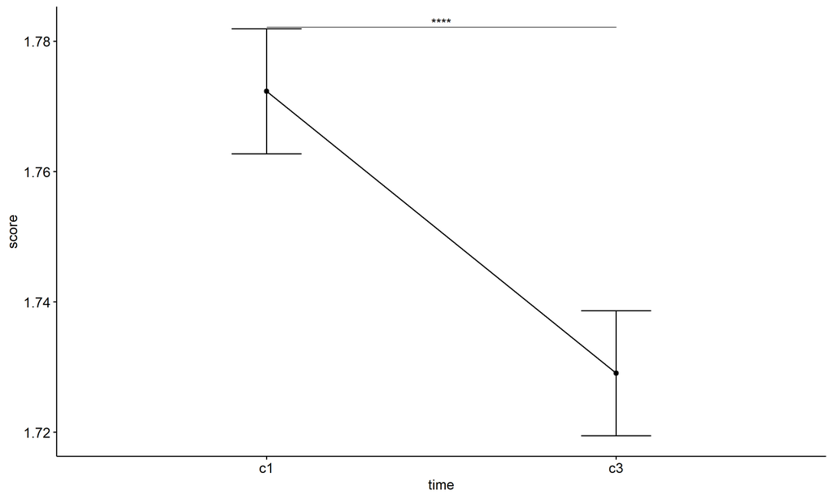

```r
pwc <- add_xy_position(pwc, x = "time", fun = "mean_se")
ggline(get_emmeans(pwc), x = "time", y = "emmean", ylab = "score") +
  geom_errorbar(aes(ymin = conf.low, ymax = conf.high), width = 0.2) +
  stat_pvalue_manual(pwc, hide.ns = T, tip.length = F)
```

# ANOVA: score ~ time*gender + Error(id/time)

## Data Preparation

```r
data <- edat[,c("aluno_id","gender","ciclo","score")]
data <- data[data$ciclo %in% c("Primeiro Ciclo","Terceiro Ciclo"),]
data$ciclo <- factor(data$ciclo, c("Primeiro Ciclo","Terceiro Ciclo"))
data <- unique(data)

wdat <- spread(data, ciclo, score)
wdat <- wdat[complete.cases(wdat),]
colnames(wdat) <- c("id","gender","c1","c3")

ldat <- gather(wdat, key = time, value = score, c1,c3) %>%
  convert_as_factor(id, time)
ldat <- remove_group_data(ldat, "score", c("time", "gender"), n.limit = 30)
ldat$gender <- factor(ldat$gender, sort(unique(ldat$gender)))
```

### Check assumptions: Identifying Outliers

```r
outliers <- identify_outliers(group_by(ldat, time, gender), score)
(outliers <- outliers[outliers$is.extreme == T,])
```

```
## # A tibble: 3 × 6
##   gender time  id                   score is.outlier is.extreme
##   <fct>  <fct> <fct>                <dbl> <lgl>      <lgl>
## 1 Female c1    TPobDcLYzJFEXhqR3YD0  3    TRUE       TRUE
## 2 Female c3    PZszZEyf9zurxXNTzPJe  3.67 TRUE       TRUE
## 3 Female c3    utURqHGd1CGfeJMrlUbh  3.67 TRUE       TRUE
```

| gender | time | id | score | is.outlier | is.extreme |
| --- | --- | --- | --- | --- | --- |
| Female | c1 | TPobDcLYzJFEXhqR3YD0 | 3.000 | TRUE | TRUE |
| Female | c3 | PZszZEyf9zurxXNTzPJe | 3.667 | TRUE | TRUE |
| Female | c3 | utURqHGd1CGfeJMrlUbh | 3.667 | TRUE | TRUE |

### Check assumptions: Normality Test

```r
(normality.df <- normality.test.per.groups(ldat, "score", c("time", "gender")))
```

```
##     var variable time gender    n  skewness   kurtosis symmetry statistic
## 1 score    score   c1 Female 1880 0.5133869 0.02977377       NO  74.45724
## 2 score    score   c1   Male 1927 0.5999686 0.42074767       NO 110.96296
## 3 score    score   c3 Female 1880 0.7554221 1.37896171       NO 203.01120
## 4 score    score   c3   Male 1927 0.6693447 0.24374569       NO 125.39596
##       method            p p.signif normality
## 1 D'Agostino 1.110223e-16     ****         -
## 2 D'Agostino 0.000000e+00     ****         -
## 3 D'Agostino 0.000000e+00     ****         -
## 4 D'Agostino 0.000000e+00     ****         -
```

| var | variable | time | gender | n | skewness | kurtosis | symmetry | statistic | method | p | p.signif | normality |
| --- | --- | --- | --- | --- | --- | --- | --- | --- | --- | --- | --- | --- |
| score | score | c1 | Female | 1880 | 0.513 | 0.030 | NO | 74.457 | D’Agostino | 0 | **** | - |
| score | score | c1 | Male | 1927 | 0.600 | 0.421 | NO | 110.963 | D’Agostino | 0 | **** | - |
| score | score | c3 | Female | 1880 | 0.755 | 1.379 | NO | 203.011 | D’Agostino | 0 | **** | - |
| score | score | c3 | Male | 1927 | 0.669 | 0.244 | NO | 125.396 | D’Agostino | 0 | **** | - |

```r
(non.ids <- unique(do.call(
  c, lapply(which(normality.df$normality == 'NO'), FUN = function(i) {
  idx = which(ldat$time == normality.df$time[i] &
                ldat$gender == normality.df$gender[i])
  getNonNormal(ldat$"score"[idx], ldat$id[idx])
}))))
```

```r
if (length(non.ids) > 0)
  ldat2 <- ldat[!ldat$id %in% non.ids,]
```

### Summary Statistics

```r
(sdat <- ldat %>% group_by(time, gender) %>%
   get_summary_stats(score, type = "mean_sd"))
```

```
## # A tibble: 4 × 6
##   gender time  variable     n  mean    sd
##   <fct>  <fct> <fct>    <dbl> <dbl> <dbl>
## 1 Female c1    score     1880  1.79 0.314
## 2 Male   c1    score     1927  1.76 0.294
## 3 Female c3    score     1880  1.74 0.318
## 4 Male   c3    score     1927  1.72 0.31
```

| gender | time | variable | n | mean | sd |
| --- | --- | --- | --- | --- | --- |
| Female | c1 | score | 1880 | 1.791 | 0.314 |
| Male | c1 | score | 1927 | 1.755 | 0.294 |
| Female | c3 | score | 1880 | 1.738 | 0.318 |
| Male | c3 | score | 1927 | 1.719 | 0.310 |

```r
if (length(non.ids) > 0)
  (sdat <- ldat2 %>% group_by(time, gender) %>%
      get_summary_stats(score, type = "mean_sd"))
```

| gender | time | variable | n | mean | sd |
| --- | --- | --- | --- | --- | --- |
| Female | c1 | score | 1880 | 1.791 | 0.314 |
| Male | c1 | score | 1927 | 1.755 | 0.294 |
| Female | c3 | score | 1880 | 1.738 | 0.318 |
| Male | c3 | score | 1927 | 1.719 | 0.310 |

## ANOVA Computation

```r
(res.aov <- anova_test(ldat, dv = score, wid = id, between = gender, within = time))
```

```
## ANOVA Table (type III tests)
##
##        Effect DFn  DFd      F        p p<.05      ges
## 1      gender   1 3805 13.292 2.70e-04     * 0.002000
## 2        time   1 3805 44.432 3.01e-11     * 0.005000
## 3 gender:time   1 3805  1.563 2.11e-01       0.000181
```

## ANOVA Computation after removing non.normal data

```r
if (length(non.ids) > 0)
  (res.aov2 <- anova_test(ldat2, dv = score, wid = id, between = gender , within = time))
```

## PairWise Computation

```r
(pwc <- ldat %>% group_by(time) %>%
   emmeans_test(score ~ gender, detailed = T, p.adjust.method = "bonferroni"))
```

```
## # A tibble: 2 × 15
##   time  term   .y.   group1 group2 null.value estimate     se    df  conf.low
## * <fct> <chr>  <chr> <chr>  <chr>       <dbl>    <dbl>  <dbl> <dbl>     <dbl>
## 1 c1    gender score Female Male            0   0.0356 0.0100  7610  0.0160
## 2 c3    gender score Female Male            0   0.0190 0.0100  7610 -0.000668
## # ℹ 5 more variables: conf.high <dbl>, statistic <dbl>, p <dbl>, p.adj <dbl>,
## #   p.adj.signif <chr>
```

| time | term | .y. | group1 | group2 | null.value | estimate | se | df | conf.low | conf.high | statistic | p | p.adj | p.adj.signif |
| --- | --- | --- | --- | --- | --- | --- | --- | --- | --- | --- | --- | --- | --- | --- |
| c1 | gender | score | Female | Male | 0 | 0.036 | 0.01 | 7610 | 0.016 | 0.055 | 3.555 | 0.000 | 0.000 | *** |
| c3 | gender | score | Female | Male | 0 | 0.019 | 0.01 | 7610 | -0.001 | 0.039 | 1.894 | 0.058 | 0.058 | ns |

```r
(emms <- get_emmeans(pwc))
```

```
## # A tibble: 4 × 8
##   time  gender emmean      se    df conf.low conf.high method
##   <fct> <fct>   <dbl>   <dbl> <dbl>    <dbl>     <dbl> <chr>
## 1 c1    Female   1.79 0.00713  7610     1.78      1.80 Emmeans test
## 2 c1    Male     1.75 0.00704  7610     1.74      1.77 Emmeans test
## 3 c3    Female   1.74 0.00713  7610     1.72      1.75 Emmeans test
## 4 c3    Male     1.72 0.00704  7610     1.71      1.73 Emmeans test
```

| time | gender | emmean | se | df | conf.low | conf.high | method |
| --- | --- | --- | --- | --- | --- | --- | --- |
| c1 | Female | 1.791 | 0.007 | 7610 | 1.777 | 1.805 | Emmeans test |
| c1 | Male | 1.755 | 0.007 | 7610 | 1.741 | 1.769 | Emmeans test |
| c3 | Female | 1.738 | 0.007 | 7610 | 1.724 | 1.752 | Emmeans test |
| c3 | Male | 1.719 | 0.007 | 7610 | 1.705 | 1.733 | Emmeans test |

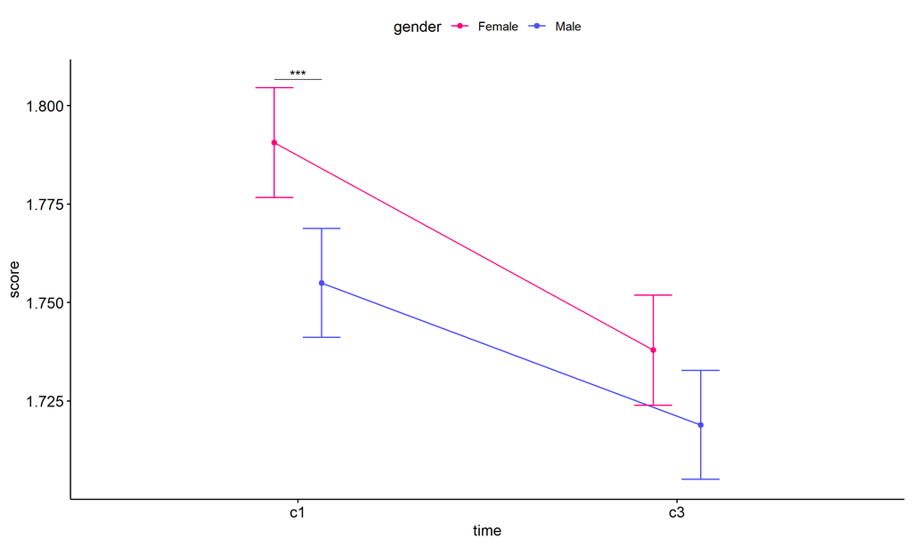

```r
pwc <- add_xy_position(pwc, x = "time", fun = "mean_se", dodge = 0.25)
pd <- position_dodge(width = 0.25)
ggline(emms, x = "time", y = "emmean", color = "gender",
       palette = c("#FF007F","#4D4DFF"),
       position = pd, ylab = "score") +
  geom_errorbar(aes(ymin = conf.low, ymax = conf.high, color = gender),
                position = pd, width = 0.2) +
  stat_pvalue_manual(pwc, hide.ns = T, tip.length = F, linetype = 1)
```

```r
(pwc <- ldat %>% group_by(gender) %>%
    emmeans_test(score ~ time, detailed = T, p.adjust.method = "bonferroni"))
```

```
## # A tibble: 2 × 15
##   gender term  .y.   group1 group2 null.value estimate      se    df conf.low
## * <fct>  <chr> <chr> <chr>  <chr>       <dbl>    <dbl>   <dbl> <dbl>    <dbl>
## 1 Female time  score c1     c3              0   0.0527 0.0101   7610   0.0330
## 2 Male   time  score c1     c3              0   0.0361 0.00996  7610   0.0165
## # ℹ 5 more variables: conf.high <dbl>, statistic <dbl>, p <dbl>, p.adj <dbl>,
## #   p.adj.signif <chr>
```

| gender | term | .y. | group1 | group2 | null.value | estimate | se | df | conf.low | conf.high | statistic | p | p.adj | p.adj.signif |
| --- | --- | --- | --- | --- | --- | --- | --- | --- | --- | --- | --- | --- | --- | --- |
| Female | time | score | c1 | c3 | 0 | 0.053 | 0.01 | 7610 | 0.033 | 0.072 | 5.228 | 0 | 0 | **** |
| Male | time | score | c1 | c3 | 0 | 0.036 | 0.01 | 7610 | 0.017 | 0.056 | 3.621 | 0 | 0 | *** |

```r
(emms <- get_emmeans(pwc))
```

```
## # A tibble: 4 × 8
##   gender time  emmean      se    df conf.low conf.high method
##   <fct>  <fct>  <dbl>   <dbl> <dbl>    <dbl>     <dbl> <chr>
## 1 Female c1      1.79 0.00713  7610     1.78      1.80 Emmeans test
## 2 Female c3      1.74 0.00713  7610     1.72      1.75 Emmeans test
## 3 Male   c1      1.75 0.00704  7610     1.74      1.77 Emmeans test
## 4 Male   c3      1.72 0.00704  7610     1.71      1.73 Emmeans test
```

| gender | time | emmean | se | df | conf.low | conf.high | method |
| --- | --- | --- | --- | --- | --- | --- | --- |
| Female | c1 | 1.791 | 0.007 | 7610 | 1.777 | 1.805 | Emmeans test |
| Female | c3 | 1.738 | 0.007 | 7610 | 1.724 | 1.752 | Emmeans test |
| Male | c1 | 1.755 | 0.007 | 7610 | 1.741 | 1.769 | Emmeans test |
| Male | c3 | 1.719 | 0.007 | 7610 | 1.705 | 1.733 | Emmeans test |

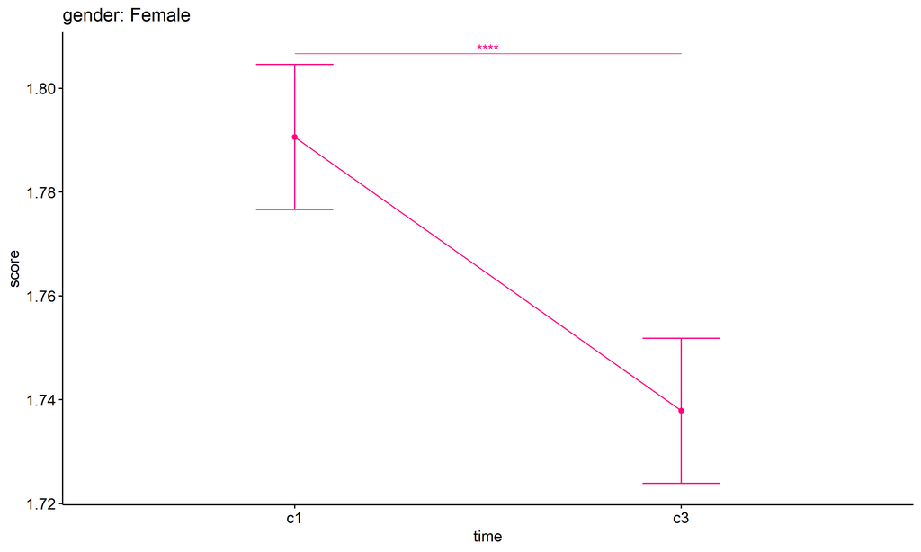

```r
emms.gg <- emms[which(emms$gender == "Female"),]
if (nrow(emms.gg) > 0)
  ggline(emms.gg, x = "time", y = "emmean", color = "#FF007F", ylab = "score") +
    geom_errorbar(aes(ymin = conf.low, ymax = conf.high),
                  width = 0.2, color = "#FF007F") +
    stat_pvalue_manual(
      add_xy_position(pwc[which(pwc$gender == "Female"),],
                      x = "time", fun = "mean_se"),
      hide.ns = T, color = "#FF007F", tip.length = F) +
    labs(title = "gender: Female")+
    theme(legend.text = element_blank())
```

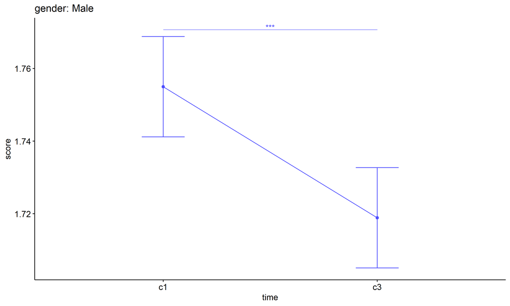

```r
emms.gg <- emms[which(emms$gender == "Male"),]
if (nrow(emms.gg) > 0)
  ggline(emms.gg, x = "time", y = "emmean", color = "#4D4DFF", ylab = "score") +
    geom_errorbar(aes(ymin = conf.low, ymax = conf.high),
                  width = 0.2, color = "#4D4DFF") +
    stat_pvalue_manual(
      add_xy_position(pwc[which(pwc$gender == "Male"),],
                      x = "time", fun = "mean_se"),
      hide.ns = T, color = "#4D4DFF", tip.length = F) +
    labs(title = "gender: Male")+
    theme(legend.text = element_blank())
```

## PairWise Computation after removing non.normal data

```r
if (length(non.ids) > 0)
  (pwc2 <- ldat2 %>% group_by(time) %>%
     emmeans_test(score ~ gender, detailed = T, p.adjust.method = "bonferroni"))
```

```r
if (length(non.ids) > 0)
  (emms2 <- get_emmeans(pwc2))
```

```r
if (length(non.ids) > 0) {
  pwc2 <- add_xy_position(pwc2, x = "time", fun = "mean_se", dodge = 0.25)
  pd2 <- position_dodge(width = 0.25)

  ggline(emms2, x = "time", y = "emmean", color = "gender",
         palette = c("#FF007F","#4D4DFF"),
         position = pd, ylab = "score") +
    geom_errorbar(aes(ymin = conf.low, ymax = conf.high, color = gender),
                position = pd, width = 0.2) +
    stat_pvalue_manual(pwc2, hide.ns = T, tip.length = F, linetype = 1)
}
```

```r
if (length(non.ids) > 0)
  (pwc2 <- ldat2 %>% group_by(gender) %>%
     emmeans_test(score ~ time, detailed = T, p.adjust.method = "bonferroni"))
```

```r
if (length(non.ids) > 0)
  (emms2 <- get_emmeans(pwc2))
```

```r
if (length(non.ids) > 0) {
  emms.gg <- emms2[which(emms2$gender == "Female"),]
  if (nrow(emms.gg) > 0)
    ggline(emms.gg, x = "time", y = "emmean", color = "#FF007F", ylab = "score") +
    geom_errorbar(aes(ymin = conf.low, ymax = conf.high),
                  width = 0.2, color = "#FF007F") +
    stat_pvalue_manual(
      add_xy_position(pwc[which(pwc$gender == "Female"),],
                      x = "time", fun = "mean_se"),
      hide.ns = T, color = "#FF007F", tip.length = F) +
    labs(title = "gender: Female") +
    theme(legend.text = element_blank())
}
```

```r
if (length(non.ids) > 0) {
  emms.gg <- emms2[which(emms2$gender == "Male"),]
  if (nrow(emms.gg) > 0)
    ggline(emms.gg, x = "time", y = "emmean", color = "#4D4DFF", ylab = "score") +
    geom_errorbar(aes(ymin = conf.low, ymax = conf.high),
                  width = 0.2, color = "#4D4DFF") +
    stat_pvalue_manual(
      add_xy_position(pwc[which(pwc$gender == "Male"),],
                      x = "time", fun = "mean_se"),
      hide.ns = T, color = "#4D4DFF", tip.length = F) +
    labs(title = "gender: Male") +
    theme(legend.text = element_blank())
}
```

# ANOVA: score ~ time*localizacao + Error(id/time)

## Data Preparation

```r
data <- edat[,c("aluno_id","localizacao","ciclo","score")]
data <- data[data$ciclo %in% c("Primeiro Ciclo","Terceiro Ciclo"),]
data$ciclo <- factor(data$ciclo, c("Primeiro Ciclo","Terceiro Ciclo"))
data <- unique(data)

wdat <- spread(data, ciclo, score)
wdat <- wdat[complete.cases(wdat),]
colnames(wdat) <- c("id","localizacao","c1","c3")

ldat <- gather(wdat, key = time, value = score, c1,c3) %>%
  convert_as_factor(id, time)
ldat <- remove_group_data(ldat, "score", c("time", "localizacao"), n.limit = 30)
ldat$localizacao <- factor(ldat$localizacao, sort(unique(ldat$localizacao)))
```

### Check assumptions: Identifying Outliers

```r
outliers <- identify_outliers(group_by(ldat, time, localizacao), score)
(outliers <- outliers[outliers$is.extreme == T,])
```

```
## # A tibble: 3 × 6
##   localizacao time  id                   score is.outlier is.extreme
##   <fct>       <fct> <fct>                <dbl> <lgl>      <lgl>
## 1 Rural       c1    TPobDcLYzJFEXhqR3YD0  3    TRUE       TRUE
## 2 Rural       c3    PZszZEyf9zurxXNTzPJe  3.67 TRUE       TRUE
## 3 Urbana      c3    utURqHGd1CGfeJMrlUbh  3.67 TRUE       TRUE
```

| localizacao | time | id | score | is.outlier | is.extreme |
| --- | --- | --- | --- | --- | --- |
| Rural | c1 | TPobDcLYzJFEXhqR3YD0 | 3.000 | TRUE | TRUE |
| Rural | c3 | PZszZEyf9zurxXNTzPJe | 3.667 | TRUE | TRUE |
| Urbana | c3 | utURqHGd1CGfeJMrlUbh | 3.667 | TRUE | TRUE |

### Check assumptions: Normality Test

```r
(normality.df <- normality.test.per.groups(ldat, "score", c("time", "localizacao")))
```

```
##     var variable time localizacao    n  skewness   kurtosis symmetry statistic
## 1 score    score   c1       Rural  683 0.4094532 0.09418107      YES  18.61357
## 2 score    score   c1      Urbana 3314 0.5805862 0.26417298       NO 170.29426
## 3 score    score   c3       Rural  683 0.6230676 0.60616631       NO  46.16632
## 4 score    score   c3      Urbana 3314 0.7203180 0.81299935       NO 283.70866
##       method            p p.signif normality
## 1 D'Agostino 9.080605e-05      ***         -
## 2 D'Agostino 0.000000e+00     ****         -
## 3 D'Agostino 9.443002e-11     ****         -
## 4 D'Agostino 0.000000e+00     ****         -
```

| var | variable | time | localizacao | n | skewness | kurtosis | symmetry | statistic | method | p | p.signif | normality |
| --- | --- | --- | --- | --- | --- | --- | --- | --- | --- | --- | --- | --- |
| score | score | c1 | Rural | 683 | 0.409 | 0.094 | YES | 18.614 | D’Agostino | 0 | *** | - |
| score | score | c1 | Urbana | 3314 | 0.581 | 0.264 | NO | 170.294 | D’Agostino | 0 | **** | - |
| score | score | c3 | Rural | 683 | 0.623 | 0.606 | NO | 46.166 | D’Agostino | 0 | **** | - |
| score | score | c3 | Urbana | 3314 | 0.720 | 0.813 | NO | 283.709 | D’Agostino | 0 | **** | - |

```r
(non.ids <- unique(do.call(
  c, lapply(which(normality.df$normality == 'NO'), FUN = function(i) {
  idx = which(ldat$time == normality.df$time[i] &
                ldat$localizacao == normality.df$localizacao[i])
  getNonNormal(ldat$"score"[idx], ldat$id[idx])
}))))
```

```r
if (length(non.ids) > 0)
  ldat2 <- ldat[!ldat$id %in% non.ids,]
```

### Summary Statistics

```r
(sdat <- ldat %>% group_by(time, localizacao) %>%
   get_summary_stats(score, type = "mean_sd"))
```

```
## # A tibble: 4 × 6
##   localizacao time  variable     n  mean    sd
##   <fct>       <fct> <fct>    <dbl> <dbl> <dbl>
## 1 Rural       c1    score      683  1.83 0.309
## 2 Urbana      c1    score     3314  1.76 0.302
## 3 Rural       c3    score      683  1.81 0.345
## 4 Urbana      c3    score     3314  1.71 0.306
```

| localizacao | time | variable | n | mean | sd |
| --- | --- | --- | --- | --- | --- |
| Rural | c1 | score | 683 | 1.831 | 0.309 |
| Urbana | c1 | score | 3314 | 1.760 | 0.302 |
| Rural | c3 | score | 683 | 1.809 | 0.345 |
| Urbana | c3 | score | 3314 | 1.713 | 0.306 |

```r
if (length(non.ids) > 0)
  (sdat <- ldat2 %>% group_by(time, localizacao) %>%
      get_summary_stats(score, type = "mean_sd"))
```

| localizacao | time | variable | n | mean | sd |
| --- | --- | --- | --- | --- | --- |
| Rural | c1 | score | 683 | 1.831 | 0.309 |
| Urbana | c1 | score | 3314 | 1.760 | 0.302 |
| Rural | c3 | score | 683 | 1.809 | 0.345 |
| Urbana | c3 | score | 3314 | 1.713 | 0.306 |

## ANOVA Computation

```r
(res.aov <- anova_test(ldat, dv = score, wid = id, between = localizacao, within = time))
```

```
## ANOVA Table (type III tests)
##
##             Effect DFn  DFd      F        p p<.05      ges
## 1      localizacao   1 3995 74.156 1.02e-17     * 0.010000
## 2             time   1 3995 16.344 5.38e-05     * 0.002000
## 3 localizacao:time   1 3995  2.185 1.39e-01       0.000243
```

## ANOVA Computation after removing non.normal data

```r
if (length(non.ids) > 0)
  (res.aov2 <- anova_test(ldat2, dv = score, wid = id, between = localizacao , within = time))
```

## PairWise Computation

```r
(pwc <- ldat %>% group_by(time) %>%
   emmeans_test(score ~ localizacao, detailed = T, p.adjust.method = "bonferroni"))
```

```
## # A tibble: 2 × 15
##   time  term       .y.   group1 group2 null.value estimate     se    df conf.low
## * <fct> <chr>      <chr> <chr>  <chr>       <dbl>    <dbl>  <dbl> <dbl>    <dbl>
## 1 c1    localizac… score Rural  Urbana          0   0.0703 0.0129  7990   0.0450
## 2 c3    localizac… score Rural  Urbana          0   0.0958 0.0129  7990   0.0705
## # ℹ 5 more variables: conf.high <dbl>, statistic <dbl>, p <dbl>, p.adj <dbl>,
## #   p.adj.signif <chr>
```

| time | term | .y. | group1 | group2 | null.value | estimate | se | df | conf.low | conf.high | statistic | p | p.adj | p.adj.signif |
| --- | --- | --- | --- | --- | --- | --- | --- | --- | --- | --- | --- | --- | --- | --- |
| c1 | localizacao | score | Rural | Urbana | 0 | 0.070 | 0.013 | 7990 | 0.045 | 0.096 | 5.435 | 0 | 0 | **** |
| c3 | localizacao | score | Rural | Urbana | 0 | 0.096 | 0.013 | 7990 | 0.070 | 0.121 | 7.405 | 0 | 0 | **** |

```r
(emms <- get_emmeans(pwc))
```

```
## # A tibble: 4 × 8
##   time  localizacao emmean      se    df conf.low conf.high method
##   <fct> <fct>        <dbl>   <dbl> <dbl>    <dbl>     <dbl> <chr>
## 1 c1    Rural         1.83 0.0118   7990     1.81      1.85 Emmeans test
## 2 c1    Urbana        1.76 0.00535  7990     1.75      1.77 Emmeans test
## 3 c3    Rural         1.81 0.0118   7990     1.79      1.83 Emmeans test
## 4 c3    Urbana        1.71 0.00535  7990     1.70      1.72 Emmeans test
```

| time | localizacao | emmean | se | df | conf.low | conf.high | method |
| --- | --- | --- | --- | --- | --- | --- | --- |
| c1 | Rural | 1.831 | 0.012 | 7990 | 1.808 | 1.854 | Emmeans test |
| c1 | Urbana | 1.760 | 0.005 | 7990 | 1.750 | 1.771 | Emmeans test |
| c3 | Rural | 1.809 | 0.012 | 7990 | 1.785 | 1.832 | Emmeans test |
| c3 | Urbana | 1.713 | 0.005 | 7990 | 1.702 | 1.723 | Emmeans test |

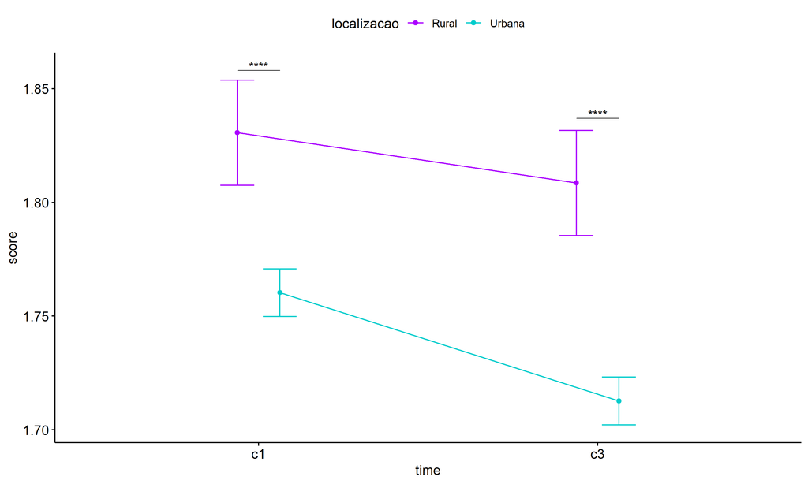

```r
pwc <- add_xy_position(pwc, x = "time", fun = "mean_se", dodge = 0.25)
pd <- position_dodge(width = 0.25)
ggline(emms, x = "time", y = "emmean", color = "localizacao",
       palette = c("#AA00FF","#00CCCC"),
       position = pd, ylab = "score") +
  geom_errorbar(aes(ymin = conf.low, ymax = conf.high, color = localizacao),
                position = pd, width = 0.2) +
  stat_pvalue_manual(pwc, hide.ns = T, tip.length = F, linetype = 1)
```

```r
(pwc <- ldat %>% group_by(localizacao) %>%
    emmeans_test(score ~ time, detailed = T, p.adjust.method = "bonferroni"))
```

```
## # A tibble: 2 × 15
##   localizacao term  .y.   group1 group2 null.value estimate      se    df
## * <fct>       <chr> <chr> <chr>  <chr>       <dbl>    <dbl>   <dbl> <dbl>
## 1 Rural       time  score c1     c3              0   0.0221 0.0167   7990
## 2 Urbana      time  score c1     c3              0   0.0476 0.00757  7990
## # ℹ 6 more variables: conf.low <dbl>, conf.high <dbl>, statistic <dbl>,
## #   p <dbl>, p.adj <dbl>, p.adj.signif <chr>
```

| localizacao | term | .y. | group1 | group2 | null.value | estimate | se | df | conf.low | conf.high | statistic | p | p.adj | p.adj.signif |
| --- | --- | --- | --- | --- | --- | --- | --- | --- | --- | --- | --- | --- | --- | --- |
| Rural | time | score | c1 | c3 | 0 | 0.022 | 0.017 | 7990 | -0.011 | 0.055 | 1.327 | 0.184 | 0.184 | ns |
| Urbana | time | score | c1 | c3 | 0 | 0.048 | 0.008 | 7990 | 0.033 | 0.062 | 6.294 | 0.000 | 0.000 | **** |

```r
(emms <- get_emmeans(pwc))
```

```
## # A tibble: 4 × 8
##   localizacao time  emmean      se    df conf.low conf.high method
##   <fct>       <fct>  <dbl>   <dbl> <dbl>    <dbl>     <dbl> <chr>
## 1 Rural       c1      1.83 0.0118   7990     1.81      1.85 Emmeans test
## 2 Rural       c3      1.81 0.0118   7990     1.79      1.83 Emmeans test
## 3 Urbana      c1      1.76 0.00535  7990     1.75      1.77 Emmeans test
## 4 Urbana      c3      1.71 0.00535  7990     1.70      1.72 Emmeans test
```

| localizacao | time | emmean | se | df | conf.low | conf.high | method |
| --- | --- | --- | --- | --- | --- | --- | --- |
| Rural | c1 | 1.831 | 0.012 | 7990 | 1.808 | 1.854 | Emmeans test |
| Rural | c3 | 1.809 | 0.012 | 7990 | 1.785 | 1.832 | Emmeans test |
| Urbana | c1 | 1.760 | 0.005 | 7990 | 1.750 | 1.771 | Emmeans test |
| Urbana | c3 | 1.713 | 0.005 | 7990 | 1.702 | 1.723 | Emmeans test |

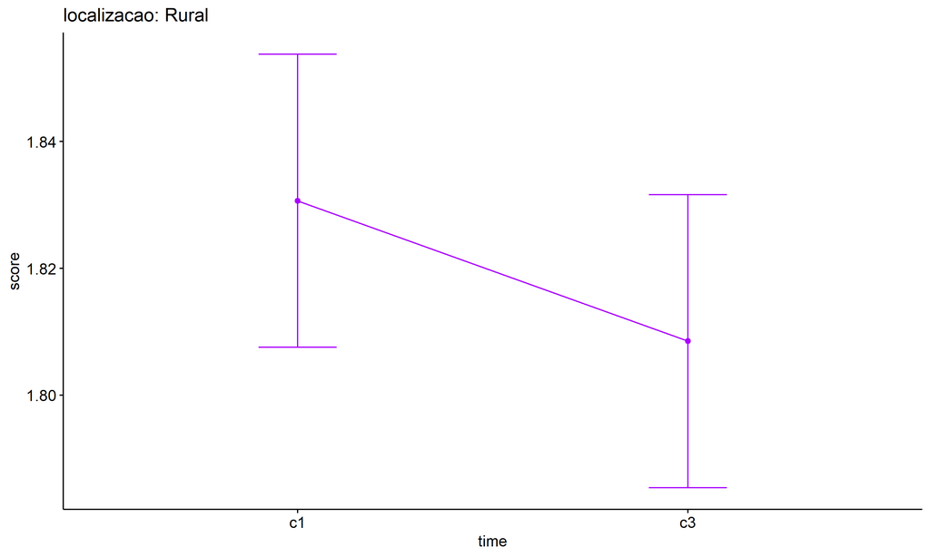

```r
emms.gg <- emms[which(emms$localizacao == "Rural"),]
if (nrow(emms.gg) > 0)
  ggline(emms.gg, x = "time", y = "emmean", color = "#AA00FF", ylab = "score") +
    geom_errorbar(aes(ymin = conf.low, ymax = conf.high),
                  width = 0.2, color = "#AA00FF") +
    stat_pvalue_manual(
      add_xy_position(pwc[which(pwc$localizacao == "Rural"),],
                      x = "time", fun = "mean_se"),
      hide.ns = T, color = "#AA00FF", tip.length = F) +
    labs(title = "localizacao: Rural")+
    theme(legend.text = element_blank())
```

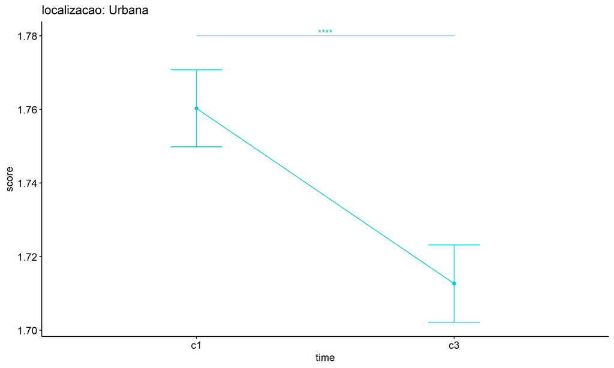

```r
emms.gg <- emms[which(emms$localizacao == "Urbana"),]
if (nrow(emms.gg) > 0)
  ggline(emms.gg, x = "time", y = "emmean", color = "#00CCCC", ylab = "score") +
    geom_errorbar(aes(ymin = conf.low, ymax = conf.high),
                  width = 0.2, color = "#00CCCC") +
    stat_pvalue_manual(
      add_xy_position(pwc[which(pwc$localizacao == "Urbana"),],
                      x = "time", fun = "mean_se"),
      hide.ns = T, color = "#00CCCC", tip.length = F) +
    labs(title = "localizacao: Urbana")+
    theme(legend.text = element_blank())
```

## PairWise Computation after removing non.normal data

```r
if (length(non.ids) > 0)
  (pwc2 <- ldat2 %>% group_by(time) %>%
     emmeans_test(score ~ localizacao, detailed = T, p.adjust.method = "bonferroni"))
```

```r
if (length(non.ids) > 0)
  (emms2 <- get_emmeans(pwc2))
```

```r
if (length(non.ids) > 0) {
  pwc2 <- add_xy_position(pwc2, x = "time", fun = "mean_se", dodge = 0.25)
  pd2 <- position_dodge(width = 0.25)

  ggline(emms2, x = "time", y = "emmean", color = "localizacao",
         palette = c("#AA00FF","#00CCCC"),
         position = pd, ylab = "score") +
    geom_errorbar(aes(ymin = conf.low, ymax = conf.high, color = localizacao),
                position = pd, width = 0.2) +
    stat_pvalue_manual(pwc2, hide.ns = T, tip.length = F, linetype = 1)
}
```

```r
if (length(non.ids) > 0)
  (pwc2 <- ldat2 %>% group_by(localizacao) %>%
     emmeans_test(score ~ time, detailed = T, p.adjust.method = "bonferroni"))
```

```r
if (length(non.ids) > 0)
  (emms2 <- get_emmeans(pwc2))
```

```r
if (length(non.ids) > 0) {
  emms.gg <- emms2[which(emms2$localizacao == "Rural"),]
  if (nrow(emms.gg) > 0)
    ggline(emms.gg, x = "time", y = "emmean", color = "#AA00FF", ylab = "score") +
    geom_errorbar(aes(ymin = conf.low, ymax = conf.high),
                  width = 0.2, color = "#AA00FF") +
    stat_pvalue_manual(
      add_xy_position(pwc[which(pwc$localizacao == "Rural"),],
                      x = "time", fun = "mean_se"),
      hide.ns = T, color = "#AA00FF", tip.length = F) +
    labs(title = "localizacao: Rural") +
    theme(legend.text = element_blank())
}
```

```r
if (length(non.ids) > 0) {
  emms.gg <- emms2[which(emms2$localizacao == "Urbana"),]
  if (nrow(emms.gg) > 0)
    ggline(emms.gg, x = "time", y = "emmean", color = "#00CCCC", ylab = "score") +
    geom_errorbar(aes(ymin = conf.low, ymax = conf.high),
                  width = 0.2, color = "#00CCCC") +
    stat_pvalue_manual(
      add_xy_position(pwc[which(pwc$localizacao == "Urbana"),],
                      x = "time", fun = "mean_se"),
      hide.ns = T, color = "#00CCCC", tip.length = F) +
    labs(title = "localizacao: Urbana") +
    theme(legend.text = element_blank())
}
```

# ANOVA: score ~ time*regiao + Error(id/time)

## Data Preparation

```r
data <- edat[,c("aluno_id","regiao","ciclo","score")]
data <- data[data$ciclo %in% c("Primeiro Ciclo","Terceiro Ciclo"),]
data$ciclo <- factor(data$ciclo, c("Primeiro Ciclo","Terceiro Ciclo"))
data <- unique(data)

wdat <- spread(data, ciclo, score)
wdat <- wdat[complete.cases(wdat),]
colnames(wdat) <- c("id","regiao","c1","c3")

ldat <- gather(wdat, key = time, value = score, c1,c3) %>%
  convert_as_factor(id, time)
ldat <- remove_group_data(ldat, "score", c("time", "regiao"), n.limit = 30)
ldat$regiao <- factor(ldat$regiao, sort(unique(ldat$regiao)))
```

### Check assumptions: Identifying Outliers

```r
outliers <- identify_outliers(group_by(ldat, time, regiao), score)
(outliers <- outliers[outliers$is.extreme == T,])
```

```
## # A tibble: 6 × 6
##   regiao   time  id                   score is.outlier is.extreme
##   <fct>    <fct> <fct>                <dbl> <lgl>      <lgl>
## 1 Nordeste c1    TPobDcLYzJFEXhqR3YD0  3    TRUE       TRUE
## 2 Norte    c1    aQKm1fE5VWhl7lV4MbTV  3    TRUE       TRUE
## 3 Nordeste c3    K7TMBHPukqALYKzvf7cx  3    TRUE       TRUE
## 4 Nordeste c3    lXWIkEauYtN6dk4nl8YX  3    TRUE       TRUE
## 5 Nordeste c3    PZszZEyf9zurxXNTzPJe  3.67 TRUE       TRUE
## 6 Norte    c3    utURqHGd1CGfeJMrlUbh  3.67 TRUE       TRUE
```

| regiao | time | id | score | is.outlier | is.extreme |
| --- | --- | --- | --- | --- | --- |
| Nordeste | c1 | TPobDcLYzJFEXhqR3YD0 | 3.000 | TRUE | TRUE |
| Norte | c1 | aQKm1fE5VWhl7lV4MbTV | 3.000 | TRUE | TRUE |
| Nordeste | c3 | K7TMBHPukqALYKzvf7cx | 3.000 | TRUE | TRUE |
| Nordeste | c3 | lXWIkEauYtN6dk4nl8YX | 3.000 | TRUE | TRUE |
| Nordeste | c3 | PZszZEyf9zurxXNTzPJe | 3.667 | TRUE | TRUE |
| Norte | c3 | utURqHGd1CGfeJMrlUbh | 3.667 | TRUE | TRUE |

### Check assumptions: Normality Test

```r
(normality.df <- normality.test.per.groups(ldat, "score", c("time", "regiao")))
```

```
##      var variable time       regiao    n  skewness    kurtosis symmetry
## 1  score    score   c1 Centro-Oeste  288 0.6117990  0.19772059       NO
## 2  score    score   c1     Nordeste 1287 0.4125896  0.05453840      YES
## 3  score    score   c1        Norte  249 0.5210841  0.06808170       NO
## 4  score    score   c1      Sudeste 2097 0.6273437  0.41204572       NO
## 5  score    score   c1          Sul   76 0.1843028 -0.54477383      YES
## 6  score    score   c3 Centro-Oeste  288 0.4249834 -0.08564994      YES
## 7  score    score   c3     Nordeste 1287 0.7049191  0.77700533       NO
## 8  score    score   c3        Norte  249 1.0730887  2.35628193       NO
## 9  score    score   c3      Sudeste 2097 0.6472241  0.26324676       NO
## 10 score    score   c3          Sul   76 0.3682045  0.07817064      YES
##     statistic     method            p p.signif normality
## 1   17.268292 D'Agostino 1.779254e-04       **         -
## 2   34.553660 D'Agostino 3.138832e-08     ****         -
## 3   11.051960 D'Agostino 3.981965e-03        *         -
## 4  128.969207 D'Agostino 0.000000e+00     ****         -
## 5    1.171289 D'Agostino 5.567468e-01       ns       YES
## 6    8.510055 D'Agostino 1.419270e-02       ns         -
## 7  107.529822 D'Agostino 0.000000e+00     ****         -
## 8   53.874583 D'Agostino 2.001177e-12     ****         -
## 9  129.618236 D'Agostino 0.000000e+00     ****         -
## 10   2.415310 D'Agostino 2.988974e-01       ns       YES
```

| var | variable | time | regiao | n | skewness | kurtosis | symmetry | statistic | method | p | p.signif | normality |
| --- | --- | --- | --- | --- | --- | --- | --- | --- | --- | --- | --- | --- |
| score | score | c1 | Centro-Oeste | 288 | 0.612 | 0.198 | NO | 17.268 | D’Agostino | 0.000 | ** | - |
| score | score | c1 | Nordeste | 1287 | 0.413 | 0.055 | YES | 34.554 | D’Agostino | 0.000 | **** | - |
| score | score | c1 | Norte | 249 | 0.521 | 0.068 | NO | 11.052 | D’Agostino | 0.004 | * | - |
| score | score | c1 | Sudeste | 2097 | 0.627 | 0.412 | NO | 128.969 | D’Agostino | 0.000 | **** | - |
| score | score | c1 | Sul | 76 | 0.184 | -0.545 | YES | 1.171 | D’Agostino | 0.557 | ns | YES |
| score | score | c3 | Centro-Oeste | 288 | 0.425 | -0.086 | YES | 8.510 | D’Agostino | 0.014 | ns | - |
| score | score | c3 | Nordeste | 1287 | 0.705 | 0.777 | NO | 107.530 | D’Agostino | 0.000 | **** | - |
| score | score | c3 | Norte | 249 | 1.073 | 2.356 | NO | 53.875 | D’Agostino | 0.000 | **** | - |
| score | score | c3 | Sudeste | 2097 | 0.647 | 0.263 | NO | 129.618 | D’Agostino | 0.000 | **** | - |
| score | score | c3 | Sul | 76 | 0.368 | 0.078 | YES | 2.415 | D’Agostino | 0.299 | ns | YES |

```r
(non.ids <- unique(do.call(
  c, lapply(which(normality.df$normality == 'NO'), FUN = function(i) {
  idx = which(ldat$time == normality.df$time[i] &
                ldat$regiao == normality.df$regiao[i])
  getNonNormal(ldat$"score"[idx], ldat$id[idx])
}))))
```

```r
if (length(non.ids) > 0)
  ldat2 <- ldat[!ldat$id %in% non.ids,]
```

### Summary Statistics

```r
(sdat <- ldat %>% group_by(time, regiao) %>%
   get_summary_stats(score, type = "mean_sd"))
```

```
## # A tibble: 10 × 6
##    regiao       time  variable     n  mean    sd
##    <fct>        <fct> <fct>    <dbl> <dbl> <dbl>
##  1 Centro-Oeste c1    score      288  1.77 0.28
##  2 Nordeste     c1    score     1287  1.81 0.315
##  3 Norte        c1    score      249  1.83 0.319
##  4 Sudeste      c1    score     2097  1.74 0.292
##  5 Sul          c1    score       76  1.91 0.323
##  6 Centro-Oeste c3    score      288  1.74 0.279
##  7 Nordeste     c3    score     1287  1.76 0.334
##  8 Norte        c3    score      249  1.80 0.357
##  9 Sudeste      c3    score     2097  1.70 0.3
## 10 Sul          c3    score       76  1.73 0.312
```

| regiao | time | variable | n | mean | sd |
| --- | --- | --- | --- | --- | --- |
| Centro-Oeste | c1 | score | 288 | 1.767 | 0.280 |
| Nordeste | c1 | score | 1287 | 1.811 | 0.315 |
| Norte | c1 | score | 249 | 1.829 | 0.319 |
| Sudeste | c1 | score | 2097 | 1.737 | 0.292 |
| Sul | c1 | score | 76 | 1.910 | 0.323 |
| Centro-Oeste | c3 | score | 288 | 1.737 | 0.279 |
| Nordeste | c3 | score | 1287 | 1.760 | 0.334 |
| Norte | c3 | score | 249 | 1.796 | 0.357 |
| Sudeste | c3 | score | 2097 | 1.701 | 0.300 |
| Sul | c3 | score | 76 | 1.732 | 0.312 |

```r
if (length(non.ids) > 0)
  (sdat <- ldat2 %>% group_by(time, regiao) %>%
      get_summary_stats(score, type = "mean_sd"))
```

| regiao | time | variable | n | mean | sd |
| --- | --- | --- | --- | --- | --- |
| Centro-Oeste | c1 | score | 288 | 1.767 | 0.280 |
| Nordeste | c1 | score | 1287 | 1.811 | 0.315 |
| Norte | c1 | score | 249 | 1.829 | 0.319 |
| Sudeste | c1 | score | 2097 | 1.737 | 0.292 |
| Sul | c1 | score | 76 | 1.910 | 0.323 |
| Centro-Oeste | c3 | score | 288 | 1.737 | 0.279 |
| Nordeste | c3 | score | 1287 | 1.760 | 0.334 |
| Norte | c3 | score | 249 | 1.796 | 0.357 |
| Sudeste | c3 | score | 2097 | 1.701 | 0.300 |
| Sul | c3 | score | 76 | 1.732 | 0.312 |

## ANOVA Computation

```r
(res.aov <- anova_test(ldat, dv = score, wid = id, between = regiao, within = time))
```

```
## ANOVA Table (type III tests)
##
##        Effect DFn  DFd      F        p p<.05   ges
## 1      regiao   4 3992 23.931 1.37e-19     * 0.013
## 2        time   1 3992 29.394 6.25e-08     * 0.003
## 3 regiao:time   4 3992  2.412 4.70e-02     * 0.001
```

## ANOVA Computation after removing non.normal data

```r
if (length(non.ids) > 0)
  (res.aov2 <- anova_test(ldat2, dv = score, wid = id, between = regiao , within = time))
```

## PairWise Computation

```r
(pwc <- ldat %>% group_by(time) %>%
   emmeans_test(score ~ regiao, detailed = T, p.adjust.method = "bonferroni"))
```

| time | term | .y. | group1 | group2 | null.value | estimate | se | df | conf.low | conf.high | statistic | p | p.adj | p.adj.signif |
| --- | --- | --- | --- | --- | --- | --- | --- | --- | --- | --- | --- | --- | --- | --- |
| c1 | regiao | score | Centro | Oeste | 0 | -0.044 | 0.020 | 7984 | -0.083 | -0.005 | -2.199 | 0.028 | 0.279 | ns |
| c1 | regiao | score | Centro | Oeste | 0 | -0.062 | 0.027 | 7984 | -0.114 | -0.010 | -2.328 | 0.020 | 0.199 | ns |
| c1 | regiao | score | Centro | Oeste | 0 | 0.030 | 0.019 | 7984 | -0.008 | 0.068 | 1.558 | 0.119 | 1.000 | ns |
| c1 | regiao | score | Centro | Oeste | 0 | -0.143 | 0.040 | 7984 | -0.220 | -0.065 | -3.599 | 0.000 | 0.003 | ** |
| c1 | regiao | score | Nordeste | Norte | 0 | -0.018 | 0.021 | 7984 | -0.060 | 0.024 | -0.839 | 0.401 | 1.000 | ns |
| c1 | regiao | score | Nordeste | Sudeste | 0 | 0.074 | 0.011 | 7984 | 0.053 | 0.096 | 6.814 | 0.000 | 0.000 | **** |
| c1 | regiao | score | Nordeste | Sul | 0 | -0.099 | 0.036 | 7984 | -0.170 | -0.027 | -2.717 | 0.007 | 0.066 | ns |
| c1 | regiao | score | Norte | Sudeste | 0 | 0.092 | 0.021 | 7984 | 0.052 | 0.132 | 4.467 | 0.000 | 0.000 | **** |
| c1 | regiao | score | Norte | Sul | 0 | -0.081 | 0.040 | 7984 | -0.160 | -0.002 | -2.004 | 0.045 | 0.451 | ns |
| c1 | regiao | score | Sudeste | Sul | 0 | -0.173 | 0.036 | 7984 | -0.243 | -0.102 | -4.813 | 0.000 | 0.000 | **** |
| c3 | regiao | score | Centro | Oeste | 0 | -0.023 | 0.020 | 7984 | -0.063 | 0.016 | -1.171 | 0.242 | 1.000 | ns |
| c3 | regiao | score | Centro | Oeste | 0 | -0.059 | 0.027 | 7984 | -0.112 | -0.007 | -2.231 | 0.026 | 0.257 | ns |
| c3 | regiao | score | Centro | Oeste | 0 | 0.036 | 0.019 | 7984 | -0.002 | 0.074 | 1.855 | 0.064 | 0.637 | ns |
| c3 | regiao | score | Centro | Oeste | 0 | 0.004 | 0.040 | 7984 | -0.074 | 0.082 | 0.107 | 0.915 | 1.000 | ns |
| c3 | regiao | score | Nordeste | Norte | 0 | -0.036 | 0.021 | 7984 | -0.078 | 0.006 | -1.686 | 0.092 | 0.917 | ns |
| c3 | regiao | score | Nordeste | Sudeste | 0 | 0.059 | 0.011 | 7984 | 0.038 | 0.081 | 5.448 | 0.000 | 0.000 | **** |
| c3 | regiao | score | Nordeste | Sul | 0 | 0.028 | 0.036 | 7984 | -0.043 | 0.099 | 0.763 | 0.445 | 1.000 | ns |
| c3 | regiao | score | Norte | Sudeste | 0 | 0.095 | 0.021 | 7984 | 0.055 | 0.136 | 4.620 | 0.000 | 0.000 | **** |
| c3 | regiao | score | Norte | Sul | 0 | 0.064 | 0.040 | 7984 | -0.015 | 0.143 | 1.578 | 0.114 | 1.000 | ns |
| c3 | regiao | score | Sudeste | Sul | 0 | -0.032 | 0.036 | 7984 | -0.102 | 0.039 | -0.880 | 0.379 | 1.000 | ns |

```r
(emms <- get_emmeans(pwc))
```

```
## # A tibble: 10 × 8
##    time  regiao       emmean      se    df conf.low conf.high method
##    <fct> <fct>         <dbl>   <dbl> <dbl>    <dbl>     <dbl> <chr>
##  1 c1    Centro-Oeste   1.77 0.0181   7984     1.73      1.80 Emmeans test
##  2 c1    Nordeste       1.81 0.00857  7984     1.79      1.83 Emmeans test
##  3 c1    Norte          1.83 0.0195   7984     1.79      1.87 Emmeans test
##  4 c1    Sudeste        1.74 0.00672  7984     1.72      1.75 Emmeans test
##  5 c1    Sul            1.91 0.0353   7984     1.84      1.98 Emmeans test
##  6 c3    Centro-Oeste   1.74 0.0181   7984     1.70      1.77 Emmeans test
##  7 c3    Nordeste       1.76 0.00857  7984     1.74      1.78 Emmeans test
##  8 c3    Norte          1.80 0.0195   7984     1.76      1.83 Emmeans test
##  9 c3    Sudeste        1.70 0.00672  7984     1.69      1.71 Emmeans test
## 10 c3    Sul            1.73 0.0353   7984     1.66      1.80 Emmeans test
```

| time | regiao | emmean | se | df | conf.low | conf.high | method |
| --- | --- | --- | --- | --- | --- | --- | --- |
| c1 | Centro-Oeste | 1.767 | 0.018 | 7984 | 1.732 | 1.803 | Emmeans test |
| c1 | Nordeste | 1.811 | 0.009 | 7984 | 1.795 | 1.828 | Emmeans test |
| c1 | Norte | 1.829 | 0.019 | 7984 | 1.791 | 1.868 | Emmeans test |
| c1 | Sudeste | 1.737 | 0.007 | 7984 | 1.724 | 1.750 | Emmeans test |
| c1 | Sul | 1.910 | 0.035 | 7984 | 1.841 | 1.979 | Emmeans test |
| c3 | Centro-Oeste | 1.737 | 0.018 | 7984 | 1.701 | 1.772 | Emmeans test |
| c3 | Nordeste | 1.760 | 0.009 | 7984 | 1.743 | 1.777 | Emmeans test |
| c3 | Norte | 1.796 | 0.019 | 7984 | 1.758 | 1.834 | Emmeans test |
| c3 | Sudeste | 1.701 | 0.007 | 7984 | 1.688 | 1.714 | Emmeans test |
| c3 | Sul | 1.732 | 0.035 | 7984 | 1.663 | 1.802 | Emmeans test |

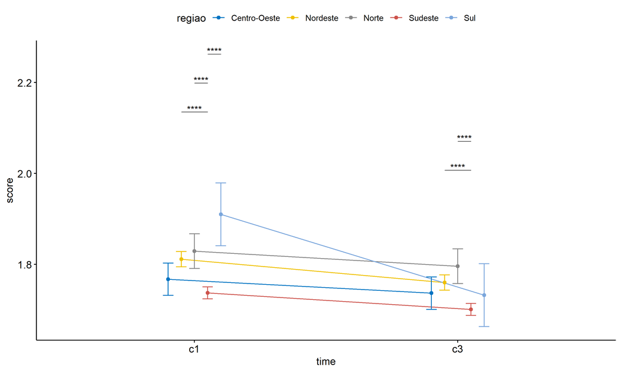

```r
pwc <- add_xy_position(pwc, x = "time", fun = "mean_se", dodge = 0.25)
pd <- position_dodge(width = 0.25)
ggline(emms, x = "time", y = "emmean", color = "regiao",
       palette = c("#0073C2FF","#EFC000FF","#868686FF","#CD534CFF","#7AA6DCFF"),
       position = pd, ylab = "score") +
  geom_errorbar(aes(ymin = conf.low, ymax = conf.high, color = regiao),
                position = pd, width = 0.2) +
  stat_pvalue_manual(pwc, hide.ns = T, tip.length = F, linetype = 1)
```

```r
(pwc <- ldat %>% group_by(regiao) %>%
    emmeans_test(score ~ time, detailed = T, p.adjust.method = "bonferroni"))
```

```
## # A tibble: 5 × 15
##   regiao    term  .y.   group1 group2 null.value estimate      se    df conf.low
## * <fct>     <chr> <chr> <chr>  <chr>       <dbl>    <dbl>   <dbl> <dbl>    <dbl>
## 1 Centro-O… time  score c1     c3              0   0.0307 0.0256   7984  -0.0196
## 2 Nordeste  time  score c1     c3              0   0.0513 0.0121   7984   0.0275
## 3 Norte     time  score c1     c3              0   0.0332 0.0276   7984  -0.0208
## 4 Sudeste   time  score c1     c3              0   0.0364 0.00950  7984   0.0178
## 5 Sul       time  score c1     c3              0   0.178  0.0499   7984   0.0798
## # ℹ 5 more variables: conf.high <dbl>, statistic <dbl>, p <dbl>, p.adj <dbl>,
## #   p.adj.signif <chr>
```

| regiao | term | .y. | group1 | group2 | null.value | estimate | se | df | conf.low | conf.high | statistic | p | p.adj | p.adj.signif |
| --- | --- | --- | --- | --- | --- | --- | --- | --- | --- | --- | --- | --- | --- | --- |
| Centro-Oeste | time | score | c1 | c3 | 0 | 0.031 | 0.026 | 7984 | -0.020 | 0.081 | 1.197 | 0.231 | 0.231 | ns |
| Nordeste | time | score | c1 | c3 | 0 | 0.051 | 0.012 | 7984 | 0.028 | 0.075 | 4.230 | 0.000 | 0.000 | **** |
| Norte | time | score | c1 | c3 | 0 | 0.033 | 0.028 | 7984 | -0.021 | 0.087 | 1.206 | 0.228 | 0.228 | ns |
| Sudeste | time | score | c1 | c3 | 0 | 0.036 | 0.009 | 7984 | 0.018 | 0.055 | 3.833 | 0.000 | 0.000 | *** |
| Sul | time | score | c1 | c3 | 0 | 0.178 | 0.050 | 7984 | 0.080 | 0.275 | 3.561 | 0.000 | 0.000 | *** |

```r
(emms <- get_emmeans(pwc))
```

```
## # A tibble: 10 × 8
##    regiao       time  emmean      se    df conf.low conf.high method
##    <fct>        <fct>  <dbl>   <dbl> <dbl>    <dbl>     <dbl> <chr>
##  1 Centro-Oeste c1      1.77 0.0181   7984     1.73      1.80 Emmeans test
##  2 Centro-Oeste c3      1.74 0.0181   7984     1.70      1.77 Emmeans test
##  3 Nordeste     c1      1.81 0.00857  7984     1.79      1.83 Emmeans test
##  4 Nordeste     c3      1.76 0.00857  7984     1.74      1.78 Emmeans test
##  5 Norte        c1      1.83 0.0195   7984     1.79      1.87 Emmeans test
##  6 Norte        c3      1.80 0.0195   7984     1.76      1.83 Emmeans test
##  7 Sudeste      c1      1.74 0.00672  7984     1.72      1.75 Emmeans test
##  8 Sudeste      c3      1.70 0.00672  7984     1.69      1.71 Emmeans test
##  9 Sul          c1      1.91 0.0353   7984     1.84      1.98 Emmeans test
## 10 Sul          c3      1.73 0.0353   7984     1.66      1.80 Emmeans test
```

| regiao | time | emmean | se | df | conf.low | conf.high | method |
| --- | --- | --- | --- | --- | --- | --- | --- |
| Centro-Oeste | c1 | 1.767 | 0.018 | 7984 | 1.732 | 1.803 | Emmeans test |
| Centro-Oeste | c3 | 1.737 | 0.018 | 7984 | 1.701 | 1.772 | Emmeans test |
| Nordeste | c1 | 1.811 | 0.009 | 7984 | 1.795 | 1.828 | Emmeans test |
| Nordeste | c3 | 1.760 | 0.009 | 7984 | 1.743 | 1.777 | Emmeans test |
| Norte | c1 | 1.829 | 0.019 | 7984 | 1.791 | 1.868 | Emmeans test |
| Norte | c3 | 1.796 | 0.019 | 7984 | 1.758 | 1.834 | Emmeans test |
| Sudeste | c1 | 1.737 | 0.007 | 7984 | 1.724 | 1.750 | Emmeans test |
| Sudeste | c3 | 1.701 | 0.007 | 7984 | 1.688 | 1.714 | Emmeans test |
| Sul | c1 | 1.910 | 0.035 | 7984 | 1.841 | 1.979 | Emmeans test |
| Sul | c3 | 1.732 | 0.035 | 7984 | 1.663 | 1.802 | Emmeans test |

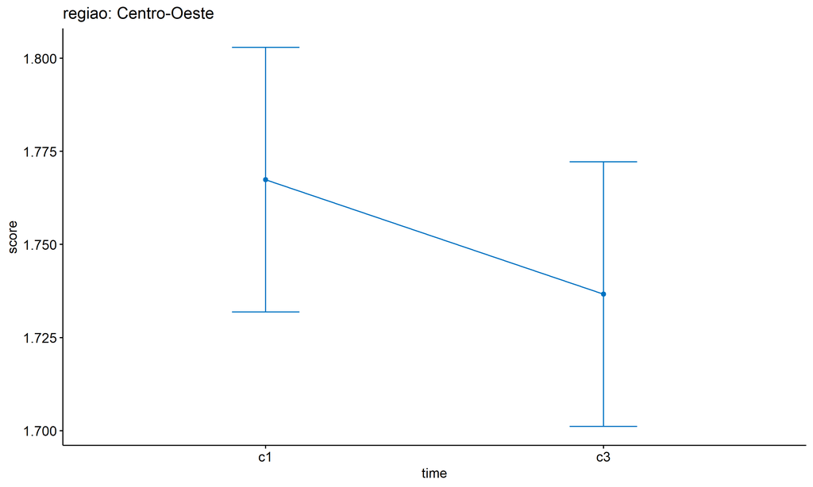

```r
emms.gg <- emms[which(emms$regiao == "Centro-Oeste"),]
if (nrow(emms.gg) > 0)
  ggline(emms.gg, x = "time", y = "emmean", color = "#0073C2FF", ylab = "score") +
    geom_errorbar(aes(ymin = conf.low, ymax = conf.high),
                  width = 0.2, color = "#0073C2FF") +
    stat_pvalue_manual(
      add_xy_position(pwc[which(pwc$regiao == "Centro-Oeste"),],
                      x = "time", fun = "mean_se"),
      hide.ns = T, color = "#0073C2FF", tip.length = F) +
    labs(title = "regiao: Centro-Oeste")+
    theme(legend.text = element_blank())
```

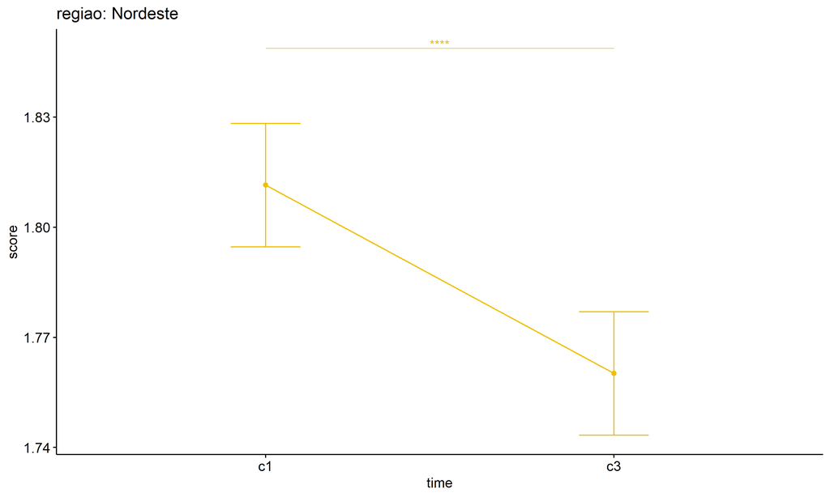

```r
emms.gg <- emms[which(emms$regiao == "Nordeste"),]
if (nrow(emms.gg) > 0)
  ggline(emms.gg, x = "time", y = "emmean", color = "#EFC000FF", ylab = "score") +
    geom_errorbar(aes(ymin = conf.low, ymax = conf.high),
                  width = 0.2, color = "#EFC000FF") +
    stat_pvalue_manual(
      add_xy_position(pwc[which(pwc$regiao == "Nordeste"),],
                      x = "time", fun = "mean_se"),
      hide.ns = T, color = "#EFC000FF", tip.length = F) +
    labs(title = "regiao: Nordeste")+
    theme(legend.text = element_blank())
```

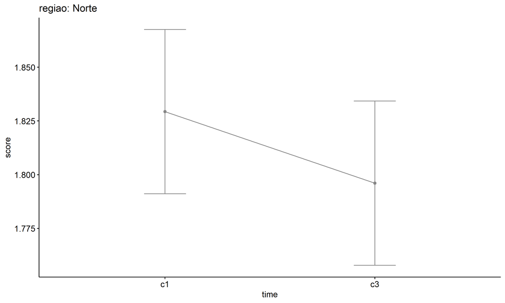

```r
emms.gg <- emms[which(emms$regiao == "Norte"),]
if (nrow(emms.gg) > 0)
  ggline(emms.gg, x = "time", y = "emmean", color = "#868686FF", ylab = "score") +
    geom_errorbar(aes(ymin = conf.low, ymax = conf.high),
                  width = 0.2, color = "#868686FF") +
    stat_pvalue_manual(
      add_xy_position(pwc[which(pwc$regiao == "Norte"),],
                      x = "time", fun = "mean_se"),
      hide.ns = T, color = "#868686FF", tip.length = F) +
    labs(title = "regiao: Norte")+
    theme(legend.text = element_blank())
```

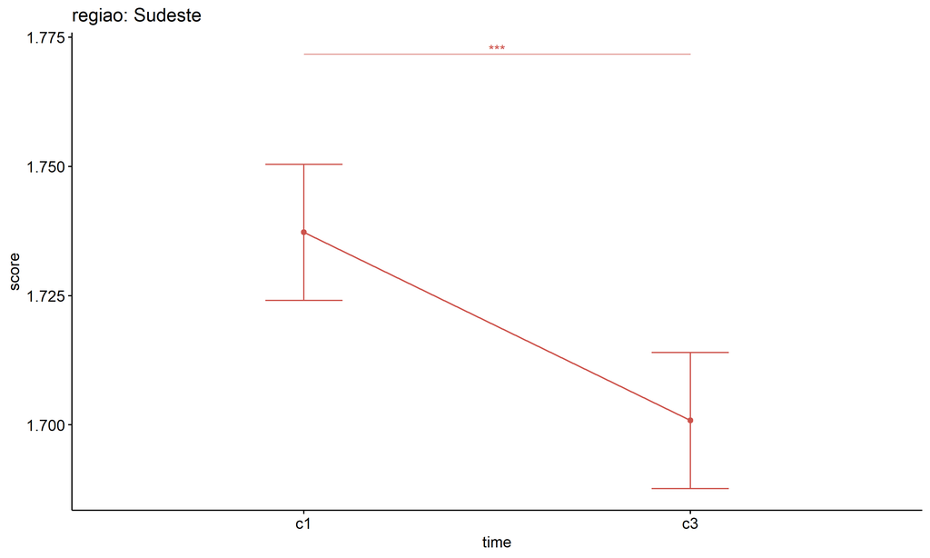

```r
emms.gg <- emms[which(emms$regiao == "Sudeste"),]
if (nrow(emms.gg) > 0)
  ggline(emms.gg, x = "time", y = "emmean", color = "#CD534CFF", ylab = "score") +
    geom_errorbar(aes(ymin = conf.low, ymax = conf.high),
                  width = 0.2, color = "#CD534CFF") +
    stat_pvalue_manual(
      add_xy_position(pwc[which(pwc$regiao == "Sudeste"),],
                      x = "time", fun = "mean_se"),
      hide.ns = T, color = "#CD534CFF", tip.length = F) +
    labs(title = "regiao: Sudeste")+
    theme(legend.text = element_blank())
```

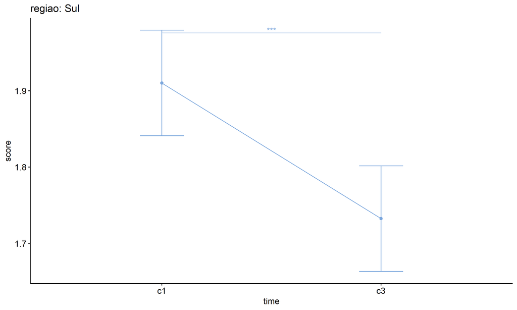

```r
emms.gg <- emms[which(emms$regiao == "Sul"),]
if (nrow(emms.gg) > 0)
  ggline(emms.gg, x = "time", y = "emmean", color = "#7AA6DCFF", ylab = "score") +
    geom_errorbar(aes(ymin = conf.low, ymax = conf.high),
                  width = 0.2, color = "#7AA6DCFF") +
    stat_pvalue_manual(
      add_xy_position(pwc[which(pwc$regiao == "Sul"),],
                      x = "time", fun = "mean_se"),
      hide.ns = T, color = "#7AA6DCFF", tip.length = F) +
    labs(title = "regiao: Sul")+
    theme(legend.text = element_blank())
```

## PairWise Computation after removing non.normal data

```r
if (length(non.ids) > 0)
  (pwc2 <- ldat2 %>% group_by(time) %>%
     emmeans_test(score ~ regiao, detailed = T, p.adjust.method = "bonferroni"))
```

```r
if (length(non.ids) > 0)
  (emms2 <- get_emmeans(pwc2))
```

```r
if (length(non.ids) > 0) {
  pwc2 <- add_xy_position(pwc2, x = "time", fun = "mean_se", dodge = 0.25)
  pd2 <- position_dodge(width = 0.25)

  ggline(emms2, x = "time", y = "emmean", color = "regiao",
         palette = c("#0073C2FF","#EFC000FF","#868686FF","#CD534CFF","#7AA6DCFF"),
         position = pd, ylab = "score") +
    geom_errorbar(aes(ymin = conf.low, ymax = conf.high, color = regiao),
                position = pd, width = 0.2) +
    stat_pvalue_manual(pwc2, hide.ns = T, tip.length = F, linetype = 1)
}
```

```r
if (length(non.ids) > 0)
  (pwc2 <- ldat2 %>% group_by(regiao) %>%
     emmeans_test(score ~ time, detailed = T, p.adjust.method = "bonferroni"))
```

```r
if (length(non.ids) > 0)
  (emms2 <- get_emmeans(pwc2))
```

```r
if (length(non.ids) > 0) {
  emms.gg <- emms2[which(emms2$regiao == "Centro-Oeste"),]
  if (nrow(emms.gg) > 0)
    ggline(emms.gg, x = "time", y = "emmean", color = "#0073C2FF", ylab = "score") +
    geom_errorbar(aes(ymin = conf.low, ymax = conf.high),
                  width = 0.2, color = "#0073C2FF") +
    stat_pvalue_manual(
      add_xy_position(pwc[which(pwc$regiao == "Centro-Oeste"),],
                      x = "time", fun = "mean_se"),
      hide.ns = T, color = "#0073C2FF", tip.length = F) +
    labs(title = "regiao: Centro-Oeste") +
    theme(legend.text = element_blank())
}
```

```r
if (length(non.ids) > 0) {
  emms.gg <- emms2[which(emms2$regiao == "Nordeste"),]
  if (nrow(emms.gg) > 0)
    ggline(emms.gg, x = "time", y = "emmean", color = "#EFC000FF", ylab = "score") +
    geom_errorbar(aes(ymin = conf.low, ymax = conf.high),
                  width = 0.2, color = "#EFC000FF") +
    stat_pvalue_manual(
      add_xy_position(pwc[which(pwc$regiao == "Nordeste"),],
                      x = "time", fun = "mean_se"),
      hide.ns = T, color = "#EFC000FF", tip.length = F) +
    labs(title = "regiao: Nordeste") +
    theme(legend.text = element_blank())
}
```

```r
if (length(non.ids) > 0) {
  emms.gg <- emms2[which(emms2$regiao == "Norte"),]
  if (nrow(emms.gg) > 0)
    ggline(emms.gg, x = "time", y = "emmean", color = "#868686FF", ylab = "score") +
    geom_errorbar(aes(ymin = conf.low, ymax = conf.high),
                  width = 0.2, color = "#868686FF") +
    stat_pvalue_manual(
      add_xy_position(pwc[which(pwc$regiao == "Norte"),],
                      x = "time", fun = "mean_se"),
      hide.ns = T, color = "#868686FF", tip.length = F) +
    labs(title = "regiao: Norte") +
    theme(legend.text = element_blank())
}
```

```r
if (length(non.ids) > 0) {
  emms.gg <- emms2[which(emms2$regiao == "Sudeste"),]
  if (nrow(emms.gg) > 0)
    ggline(emms.gg, x = "time", y = "emmean", color = "#CD534CFF", ylab = "score") +
    geom_errorbar(aes(ymin = conf.low, ymax = conf.high),
                  width = 0.2, color = "#CD534CFF") +
    stat_pvalue_manual(
      add_xy_position(pwc[which(pwc$regiao == "Sudeste"),],
                      x = "time", fun = "mean_se"),
      hide.ns = T, color = "#CD534CFF", tip.length = F) +
    labs(title = "regiao: Sudeste") +
    theme(legend.text = element_blank())
}
```

```r
if (length(non.ids) > 0) {
  emms.gg <- emms2[which(emms2$regiao == "Sul"),]
  if (nrow(emms.gg) > 0)
    ggline(emms.gg, x = "time", y = "emmean", color = "#7AA6DCFF", ylab = "score") +
    geom_errorbar(aes(ymin = conf.low, ymax = conf.high),
                  width = 0.2, color = "#7AA6DCFF") +
    stat_pvalue_manual(
      add_xy_position(pwc[which(pwc$regiao == "Sul"),],
                      x = "time", fun = "mean_se"),
      hide.ns = T, color = "#7AA6DCFF", tip.length = F) +
    labs(title = "regiao: Sul") +
    theme(legend.text = element_blank())
}
```

# ANOVA: score ~ time*porte + Error(id/time)

## Data Preparation

```r
data <- edat[,c("aluno_id","porte","ciclo","score")]
data <- data[data$ciclo %in% c("Primeiro Ciclo","Terceiro Ciclo"),]
data$ciclo <- factor(data$ciclo, c("Primeiro Ciclo","Terceiro Ciclo"))
data <- unique(data)

wdat <- spread(data, ciclo, score)
wdat <- wdat[complete.cases(wdat),]
colnames(wdat) <- c("id","porte","c1","c3")

ldat <- gather(wdat, key = time, value = score, c1,c3) %>%
  convert_as_factor(id, time)
ldat <- remove_group_data(ldat, "score", c("time", "porte"), n.limit = 30)
ldat$porte <- factor(ldat$porte, sort(unique(ldat$porte)))
```

### Check assumptions: Identifying Outliers

```r
outliers <- identify_outliers(group_by(ldat, time, porte), score)
(outliers <- outliers[outliers$is.extreme == T,])
```

```
## # A tibble: 6 × 6
##   porte                                  time  id    score is.outlier is.extreme
##   <fct>                                  <fct> <fct> <dbl> <lgl>      <lgl>
## 1 Entre 201 e 500 matrículas de escolar… c1    aQKm…  3    TRUE       TRUE
## 2 Entre 201 e 500 matrículas de escolar… c1    Sqyc…  3    TRUE       TRUE
## 3 Entre 51 e 200 matrículas de escolari… c1    TPob…  3    TRUE       TRUE
## 4 Entre 201 e 500 matrículas de escolar… c3    K7TM…  3    TRUE       TRUE
## 5 Entre 201 e 500 matrículas de escolar… c3    utUR…  3.67 TRUE       TRUE
## 6 Entre 51 e 200 matrículas de escolari… c3    PZsz…  3.67 TRUE       TRUE
```

| porte | time | id | score | is.outlier | is.extreme |
| --- | --- | --- | --- | --- | --- |
| Entre 201 e 500 matrículas de escolarização | c1 | aQKm1fE5VWhl7lV4MbTV | 3.000 | TRUE | TRUE |
| Entre 201 e 500 matrículas de escolarização | c1 | SqycP86Vzy7VCLeYFXYW | 3.000 | TRUE | TRUE |
| Entre 51 e 200 matrículas de escolarização | c1 | TPobDcLYzJFEXhqR3YD0 | 3.000 | TRUE | TRUE |
| Entre 201 e 500 matrículas de escolarização | c3 | K7TMBHPukqALYKzvf7cx | 3.000 | TRUE | TRUE |
| Entre 201 e 500 matrículas de escolarização | c3 | utURqHGd1CGfeJMrlUbh | 3.667 | TRUE | TRUE |
| Entre 51 e 200 matrículas de escolarização | c3 | PZszZEyf9zurxXNTzPJe | 3.667 | TRUE | TRUE |

### Check assumptions: Normality Test

```r
(normality.df <- normality.test.per.groups(ldat, "score", c("time", "porte")))
```

```
##     var variable time                                        porte    n
## 1 score    score   c1  Entre 201 e 500 matrículas de escolarização 1059
## 2 score    score   c1 Entre 501 e 1000 matrículas de escolarização 2315
## 3 score    score   c1   Entre 51 e 200 matrículas de escolarização  259
## 4 score    score   c1     Mais de 1000 matrículas de escolarização  344
## 5 score    score   c3  Entre 201 e 500 matrículas de escolarização 1059
## 6 score    score   c3 Entre 501 e 1000 matrículas de escolarização 2315
## 7 score    score   c3   Entre 51 e 200 matrículas de escolarização  259
## 8 score    score   c3     Mais de 1000 matrículas de escolarização  344
##    skewness   kurtosis symmetry  statistic     method            p p.signif
## 1 0.4608577  0.1760976      YES  36.219692 D'Agostino 1.364564e-08     ****
## 2 0.5518743  0.2452803       NO 109.011909 D'Agostino 0.000000e+00     ****
## 3 0.3868816 -0.1557558      YES   6.536524 D'Agostino 3.807254e-02       ns
## 4 0.7289696  0.2686084       NO  27.565555 D'Agostino 1.033275e-06     ****
## 5 0.7018367  0.8859720       NO  91.681674 D'Agostino 0.000000e+00     ****
## 6 0.6090933  0.1983048       NO 127.068499 D'Agostino 0.000000e+00     ****
## 7 1.1202673  2.8992011       NO  62.396390 D'Agostino 2.819966e-14     ****
## 8 0.8026983  0.5840285       NO  34.842637 D'Agostino 2.716549e-08     ****
##   normality
## 1         -
## 2         -
## 3         -
## 4         -
## 5         -
## 6         -
## 7         -
## 8         -
```

| var | variable | time | porte | n | skewness | kurtosis | symmetry | statistic | method | p | p.signif | normality |
| --- | --- | --- | --- | --- | --- | --- | --- | --- | --- | --- | --- | --- |
| score | score | c1 | Entre 201 e 500 matrículas de escolarização | 1059 | 0.461 | 0.176 | YES | 36.220 | D’Agostino | 0.000 | **** | - |
| score | score | c1 | Entre 501 e 1000 matrículas de escolarização | 2315 | 0.552 | 0.245 | NO | 109.012 | D’Agostino | 0.000 | **** | - |
| score | score | c1 | Entre 51 e 200 matrículas de escolarização | 259 | 0.387 | -0.156 | YES | 6.537 | D’Agostino | 0.038 | ns | - |
| score | score | c1 | Mais de 1000 matrículas de escolarização | 344 | 0.729 | 0.269 | NO | 27.566 | D’Agostino | 0.000 | **** | - |
| score | score | c3 | Entre 201 e 500 matrículas de escolarização | 1059 | 0.702 | 0.886 | NO | 91.682 | D’Agostino | 0.000 | **** | - |
| score | score | c3 | Entre 501 e 1000 matrículas de escolarização | 2315 | 0.609 | 0.198 | NO | 127.068 | D’Agostino | 0.000 | **** | - |
| score | score | c3 | Entre 51 e 200 matrículas de escolarização | 259 | 1.120 | 2.899 | NO | 62.396 | D’Agostino | 0.000 | **** | - |
| score | score | c3 | Mais de 1000 matrículas de escolarização | 344 | 0.803 | 0.584 | NO | 34.843 | D’Agostino | 0.000 | **** | - |

```r
(non.ids <- unique(do.call(
  c, lapply(which(normality.df$normality == 'NO'), FUN = function(i) {
  idx = which(ldat$time == normality.df$time[i] &
                ldat$porte == normality.df$porte[i])
  getNonNormal(ldat$"score"[idx], ldat$id[idx])
}))))
```

```r
if (length(non.ids) > 0)
  ldat2 <- ldat[!ldat$id %in% non.ids,]
```

### Summary Statistics

```r
(sdat <- ldat %>% group_by(time, porte) %>%
   get_summary_stats(score, type = "mean_sd"))
```

```
## # A tibble: 8 × 6
##   porte                                        time  variable     n  mean    sd
##   <fct>                                        <fct> <fct>    <dbl> <dbl> <dbl>
## 1 Entre 201 e 500 matrículas de escolarização  c1    score     1059  1.80 0.317
## 2 Entre 501 e 1000 matrículas de escolarização c1    score     2315  1.76 0.291
## 3 Entre 51 e 200 matrículas de escolarização   c1    score      259  1.87 0.34
## 4 Mais de 1000 matrículas de escolarização     c1    score      344  1.69 0.284
## 5 Entre 201 e 500 matrículas de escolarização  c3    score     1059  1.78 0.328
## 6 Entre 501 e 1000 matrículas de escolarização c3    score     2315  1.71 0.301
## 7 Entre 51 e 200 matrículas de escolarização   c3    score      259  1.78 0.351
## 8 Mais de 1000 matrículas de escolarização     c3    score      344  1.68 0.307
```

| porte | time | variable | n | mean | sd |
| --- | --- | --- | --- | --- | --- |
| Entre 201 e 500 matrículas de escolarização | c1 | score | 1059 | 1.804 | 0.317 |
| Entre 501 e 1000 matrículas de escolarização | c1 | score | 2315 | 1.759 | 0.291 |
| Entre 51 e 200 matrículas de escolarização | c1 | score | 259 | 1.866 | 0.340 |
| Mais de 1000 matrículas de escolarização | c1 | score | 344 | 1.688 | 0.284 |
| Entre 201 e 500 matrículas de escolarização | c3 | score | 1059 | 1.777 | 0.328 |
| Entre 501 e 1000 matrículas de escolarização | c3 | score | 2315 | 1.709 | 0.301 |
| Entre 51 e 200 matrículas de escolarização | c3 | score | 259 | 1.776 | 0.351 |
| Mais de 1000 matrículas de escolarização | c3 | score | 344 | 1.675 | 0.307 |

```r
if (length(non.ids) > 0)
  (sdat <- ldat2 %>% group_by(time, porte) %>%
      get_summary_stats(score, type = "mean_sd"))
```

[output not shown]

## ANOVA Computation

```r
(res.aov <- anova_test(ldat, dv = score, wid = id, between = porte, within = time))
```

```
## ANOVA Table (type III tests)
##
##       Effect DFn  DFd      F        p p<.05      ges
## 1      porte   3 3973 33.719 1.63e-21     * 0.014000
## 2       time   1 3973 23.583 1.24e-06     * 0.003000
## 3 porte:time   3 3973  2.443 6.20e-02       0.000823
```

## ANOVA Computation after removing non.normal data

```r
if (length(non.ids) > 0)
  (res.aov2 <- anova_test(ldat2, dv = score, wid = id, between = porte , within = time))
```

## PairWise Computation

```r
(pwc <- ldat %>% group_by(time) %>%
   emmeans_test(score ~ porte, detailed = T, p.adjust.method = "bonferroni"))
```

```
## # A tibble: 12 × 15
##    time  term  .y.   group1     group2 null.value estimate     se    df conf.low
##  * <fct> <chr> <chr> <chr>      <chr>       <dbl>    <dbl>  <dbl> <dbl>    <dbl>
##  1 c1    porte score Entre 201… Entre…          0  4.58e-2 0.0114  7946  0.0235
##  2 c1    porte score Entre 201… Entre…          0 -6.11e-2 0.0213  7946 -0.103
##  3 c1    porte score Entre 201… Mais …          0  1.16e-1 0.0190  7946  0.0786
##  4 c1    porte score Entre 501… Entre…          0 -1.07e-1 0.0201  7946 -0.146
##  5 c1    porte score Entre 501… Mais …          0  7.01e-2 0.0177  7946  0.0354
##  6 c1    porte score Entre 51 … Mais …          0  1.77e-1 0.0252  7946  0.128
##  7 c3    porte score Entre 201… Entre…          0  6.84e-2 0.0114  7946  0.0460
##  8 c3    porte score Entre 201… Entre…          0  7.15e-4 0.0213  7946 -0.0410
##  9 c3    porte score Entre 201… Mais …          0  1.02e-1 0.0190  7946  0.0643
## 10 c3    porte score Entre 501… Entre…          0 -6.76e-2 0.0201  7946 -0.107
## 11 c3    porte score Entre 501… Mais …          0  3.33e-2 0.0177  7946 -0.00150
## 12 c3    porte score Entre 51 … Mais …          0  1.01e-1 0.0252  7946  0.0514
## # ℹ 5 more variables: conf.high <dbl>, statistic <dbl>, p <dbl>, p.adj <dbl>,
## #   p.adj.signif <chr>
```

| time | term | .y. | group1 | group2 | null.value | estimate | se | df | conf.low | conf.high | statistic | p | p.adj | p.adj.signif |
| --- | --- | --- | --- | --- | --- | --- | --- | --- | --- | --- | --- | --- | --- | --- |
| c1 | porte | score | Entre 201 e 500 matrículas de escolarização | Entre 501 e 1000 matrículas de escolarização | 0 | 0.046 | 0.011 | 7946 | 0.023 | 0.068 | 4.022 | 0.000 | 0.000 | *** |
| c1 | porte | score | Entre 201 e 500 matrículas de escolarização | Entre 51 e 200 matrículas de escolarização | 0 | -0.061 | 0.021 | 7946 | -0.103 | -0.019 | -2.875 | 0.004 | 0.024 | * |
| c1 | porte | score | Entre 201 e 500 matrículas de escolarização | Mais de 1000 matrículas de escolarização | 0 | 0.116 | 0.019 | 7946 | 0.079 | 0.153 | 6.088 | 0.000 | 0.000 | **** |
| c1 | porte | score | Entre 501 e 1000 matrículas de escolarização | Entre 51 e 200 matrículas de escolarização | 0 | -0.107 | 0.020 | 7946 | -0.146 | -0.068 | -5.319 | 0.000 | 0.000 | **** |
| c1 | porte | score | Entre 501 e 1000 matrículas de escolarização | Mais de 1000 matrículas de escolarização | 0 | 0.070 | 0.018 | 7946 | 0.035 | 0.105 | 3.957 | 0.000 | 0.000 | *** |
| c1 | porte | score | Entre 51 e 200 matrículas de escolarização | Mais de 1000 matrículas de escolarização | 0 | 0.177 | 0.025 | 7946 | 0.128 | 0.227 | 7.015 | 0.000 | 0.000 | **** |
| c3 | porte | score | Entre 201 e 500 matrículas de escolarização | Entre 501 e 1000 matrículas de escolarização | 0 | 0.068 | 0.011 | 7946 | 0.046 | 0.091 | 6.006 | 0.000 | 0.000 | **** |
| c3 | porte | score | Entre 201 e 500 matrículas de escolarização | Entre 51 e 200 matrículas de escolarização | 0 | 0.001 | 0.021 | 7946 | -0.041 | 0.042 | 0.034 | 0.973 | 1.000 | ns |
| c3 | porte | score | Entre 201 e 500 matrículas de escolarização | Mais de 1000 matrículas de escolarização | 0 | 0.102 | 0.019 | 7946 | 0.064 | 0.139 | 5.337 | 0.000 | 0.000 | **** |
| c3 | porte | score | Entre 501 e 1000 matrículas de escolarização | Entre 51 e 200 matrículas de escolarização | 0 | -0.068 | 0.020 | 7946 | -0.107 | -0.028 | -3.365 | 0.001 | 0.005 | ** |
| c3 | porte | score | Entre 501 e 1000 matrículas de escolarização | Mais de 1000 matrículas de escolarização | 0 | 0.033 | 0.018 | 7946 | -0.001 | 0.068 | 1.876 | 0.061 | 0.364 | ns |
| c3 | porte | score | Entre 51 e 200 matrículas de escolarização | Mais de 1000 matrículas de escolarização | 0 | 0.101 | 0.025 | 7946 | 0.051 | 0.150 | 3.998 | 0.000 | 0.000 | *** |

```r
(emms <- get_emmeans(pwc))
```

```
## # A tibble: 8 × 8
##   time  porte                     emmean      se    df conf.low conf.high method
##   <fct> <fct>                      <dbl>   <dbl> <dbl>    <dbl>     <dbl> <chr>
## 1 c1    Entre 201 e 500 matrícul…   1.80 0.00943  7946     1.79      1.82 Emmea…
## 2 c1    Entre 501 e 1000 matrícu…   1.76 0.00638  7946     1.75      1.77 Emmea…
## 3 c1    Entre 51 e 200 matrícula…   1.87 0.0191   7946     1.83      1.90 Emmea…
## 4 c1    Mais de 1000 matrículas …   1.69 0.0165   7946     1.66      1.72 Emmea…
## 5 c3    Entre 201 e 500 matrícul…   1.78 0.00943  7946     1.76      1.80 Emmea…
## 6 c3    Entre 501 e 1000 matrícu…   1.71 0.00638  7946     1.70      1.72 Emmea…
## 7 c3    Entre 51 e 200 matrícula…   1.78 0.0191   7946     1.74      1.81 Emmea…
## 8 c3    Mais de 1000 matrículas …   1.68 0.0165   7946     1.64      1.71 Emmea…
```

| time | porte | emmean | se | df | conf.low | conf.high | method |
| --- | --- | --- | --- | --- | --- | --- | --- |
| c1 | Entre 201 e 500 matrículas de escolarização | 1.804 | 0.009 | 7946 | 1.786 | 1.823 | Emmeans test |
| c1 | Entre 501 e 1000 matrículas de escolarização | 1.759 | 0.006 | 7946 | 1.746 | 1.771 | Emmeans test |
| c1 | Entre 51 e 200 matrículas de escolarização | 1.866 | 0.019 | 7946 | 1.828 | 1.903 | Emmeans test |
| c1 | Mais de 1000 matrículas de escolarização | 1.688 | 0.017 | 7946 | 1.656 | 1.721 | Emmeans test |
| c3 | Entre 201 e 500 matrículas de escolarização | 1.777 | 0.009 | 7946 | 1.759 | 1.795 | Emmeans test |
| c3 | Entre 501 e 1000 matrículas de escolarização | 1.709 | 0.006 | 7946 | 1.696 | 1.721 | Emmeans test |
| c3 | Entre 51 e 200 matrículas de escolarização | 1.776 | 0.019 | 7946 | 1.739 | 1.814 | Emmeans test |
| c3 | Mais de 1000 matrículas de escolarização | 1.675 | 0.017 | 7946 | 1.643 | 1.708 | Emmeans test |

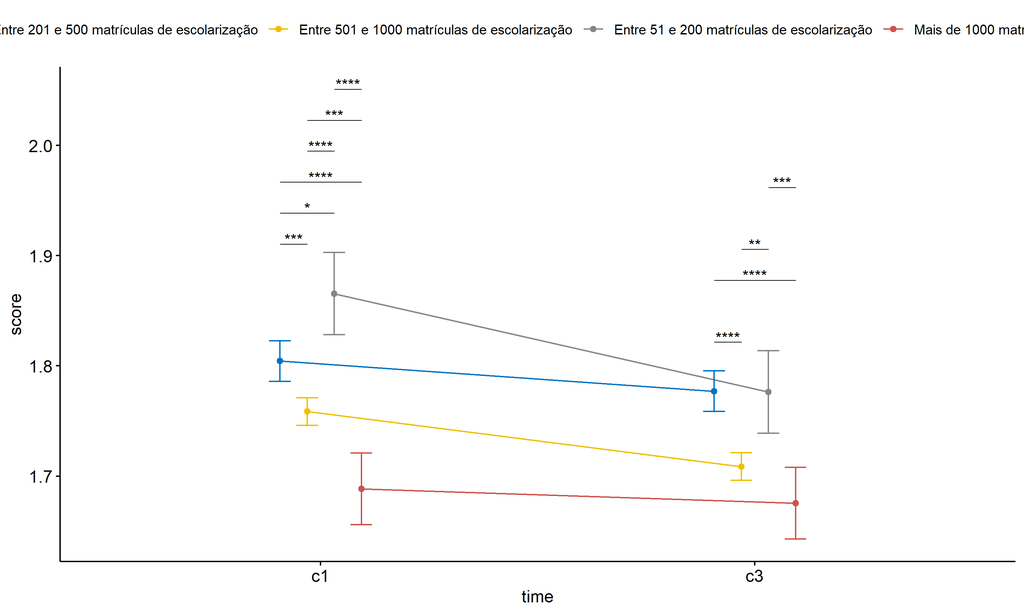

```r
pwc <- add_xy_position(pwc, x = "time", fun = "mean_se", dodge = 0.25)
pd <- position_dodge(width = 0.25)
ggline(emms, x = "time", y = "emmean", color = "porte",
       palette = c("#0073C2FF","#EFC000FF","#868686FF","#CD534CFF","#7AA6DCFF"),
       position = pd, ylab = "score") +
  geom_errorbar(aes(ymin = conf.low, ymax = conf.high, color = porte),
                position = pd, width = 0.2) +
  stat_pvalue_manual(pwc, hide.ns = T, tip.length = F, linetype = 1)
```

```r
(pwc <- ldat %>% group_by(porte) %>%
    emmeans_test(score ~ time, detailed = T, p.adjust.method = "bonferroni"))
```

```
## # A tibble: 4 × 15
##   porte     term  .y.   group1 group2 null.value estimate      se    df conf.low
## * <fct>     <chr> <chr> <chr>  <chr>       <dbl>    <dbl>   <dbl> <dbl>    <dbl>
## 1 Entre 20… time  score c1     c3              0   0.0274 0.0133   7946  0.00125
## 2 Entre 50… time  score c1     c3              0   0.0500 0.00902  7946  0.0323
## 3 Entre 51… time  score c1     c3              0   0.0892 0.0270   7946  0.0364
## 4 Mais de … time  score c1     c3              0   0.0131 0.0234   7946 -0.0328
## # ℹ 5 more variables: conf.high <dbl>, statistic <dbl>, p <dbl>, p.adj <dbl>,
## #   p.adj.signif <chr>
```

| porte | term | .y. | group1 | group2 | null.value | estimate | se | df | conf.low | conf.high | statistic | p | p.adj | p.adj.signif |
| --- | --- | --- | --- | --- | --- | --- | --- | --- | --- | --- | --- | --- | --- | --- |
| Entre 201 e 500 matrículas de escolarização | time | score | c1 | c3 | 0 | 0.027 | 0.013 | 7946 | 0.001 | 0.054 | 2.054 | 0.040 | 0.040 | * |
| Entre 501 e 1000 matrículas de escolarização | time | score | c1 | c3 | 0 | 0.050 | 0.009 | 7946 | 0.032 | 0.068 | 5.541 | 0.000 | 0.000 | **** |
| Entre 51 e 200 matrículas de escolarização | time | score | c1 | c3 | 0 | 0.089 | 0.027 | 7946 | 0.036 | 0.142 | 3.310 | 0.001 | 0.001 | *** |
| Mais de 1000 matrículas de escolarização | time | score | c1 | c3 | 0 | 0.013 | 0.023 | 7946 | -0.033 | 0.059 | 0.559 | 0.576 | 0.576 | ns |

```r
(emms <- get_emmeans(pwc))
```

```
## # A tibble: 8 × 8
##   porte                     time  emmean      se    df conf.low conf.high method
##   <fct>                     <fct>  <dbl>   <dbl> <dbl>    <dbl>     <dbl> <chr>
## 1 Entre 201 e 500 matrícul… c1      1.80 0.00943  7946     1.79      1.82 Emmea…
## 2 Entre 201 e 500 matrícul… c3      1.78 0.00943  7946     1.76      1.80 Emmea…
## 3 Entre 501 e 1000 matrícu… c1      1.76 0.00638  7946     1.75      1.77 Emmea…
## 4 Entre 501 e 1000 matrícu… c3      1.71 0.00638  7946     1.70      1.72 Emmea…
## 5 Entre 51 e 200 matrícula… c1      1.87 0.0191   7946     1.83      1.90 Emmea…
## 6 Entre 51 e 200 matrícula… c3      1.78 0.0191   7946     1.74      1.81 Emmea…
## 7 Mais de 1000 matrículas … c1      1.69 0.0165   7946     1.66      1.72 Emmea…
## 8 Mais de 1000 matrículas … c3      1.68 0.0165   7946     1.64      1.71 Emmea…
```

| porte | time | emmean | se | df | conf.low | conf.high | method |
| --- | --- | --- | --- | --- | --- | --- | --- |
| Entre 201 e 500 matrículas de escolarização | c1 | 1.804 | 0.009 | 7946 | 1.786 | 1.823 | Emmeans test |
| Entre 201 e 500 matrículas de escolarização | c3 | 1.777 | 0.009 | 7946 | 1.759 | 1.795 | Emmeans test |
| Entre 501 e 1000 matrículas de escolarização | c1 | 1.759 | 0.006 | 7946 | 1.746 | 1.771 | Emmeans test |
| Entre 501 e 1000 matrículas de escolarização | c3 | 1.709 | 0.006 | 7946 | 1.696 | 1.721 | Emmeans test |
| Entre 51 e 200 matrículas de escolarização | c1 | 1.866 | 0.019 | 7946 | 1.828 | 1.903 | Emmeans test |
| Entre 51 e 200 matrículas de escolarização | c3 | 1.776 | 0.019 | 7946 | 1.739 | 1.814 | Emmeans test |
| Mais de 1000 matrículas de escolarização | c1 | 1.688 | 0.017 | 7946 | 1.656 | 1.721 | Emmeans test |
| Mais de 1000 matrículas de escolarização | c3 | 1.675 | 0.017 | 7946 | 1.643 | 1.708 | Emmeans test |

```r
emms.gg <- emms[which(emms$porte == "Até 50 matrículas de escolarização"),]
if (nrow(emms.gg) > 0)
  ggline(emms.gg, x = "time", y = "emmean", color = "#0073C2FF", ylab = "score") +
    geom_errorbar(aes(ymin = conf.low, ymax = conf.high),
                  width = 0.2, color = "#0073C2FF") +
    stat_pvalue_manual(
      add_xy_position(pwc[which(pwc$porte == "Até 50 matrículas de escolarização"),],
                      x = "time", fun = "mean_se"),
      hide.ns = T, color = "#0073C2FF", tip.length = F) +
    labs(title = "porte: Até 50 matrículas de escolarização")+
    theme(legend.text = element_blank())
```

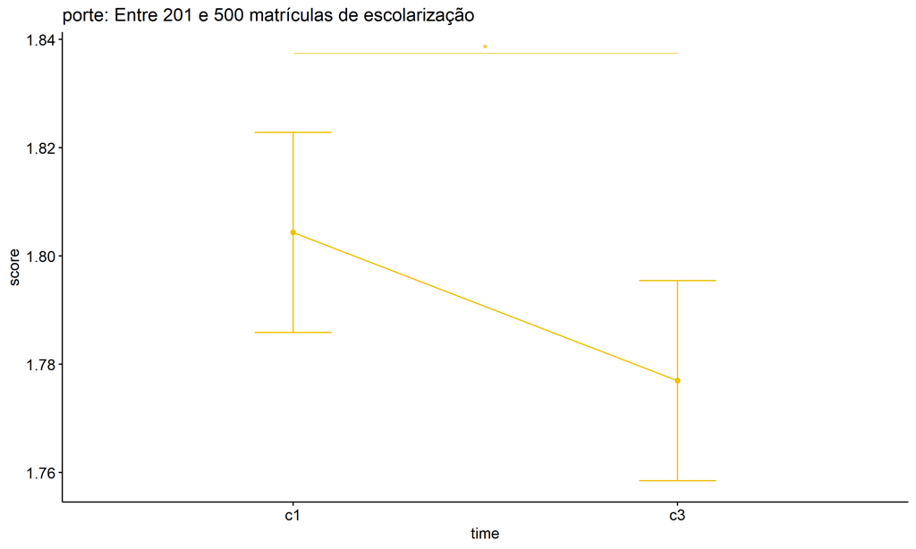

```r
emms.gg <- emms[which(emms$porte == "Entre 201 e 500 matrículas de escolarização"),]
if (nrow(emms.gg) > 0)
  ggline(emms.gg, x = "time", y = "emmean", color = "#EFC000FF", ylab = "score") +
    geom_errorbar(aes(ymin = conf.low, ymax = conf.high),
                  width = 0.2, color = "#EFC000FF") +
    stat_pvalue_manual(
      add_xy_position(pwc[which(pwc$porte == "Entre 201 e 500 matrículas de escolarização"),],
                      x = "time", fun = "mean_se"),
      hide.ns = T, color = "#EFC000FF", tip.length = F) +
    labs(title = "porte: Entre 201 e 500 matrículas de escolarização")+
    theme(legend.text = element_blank())
```

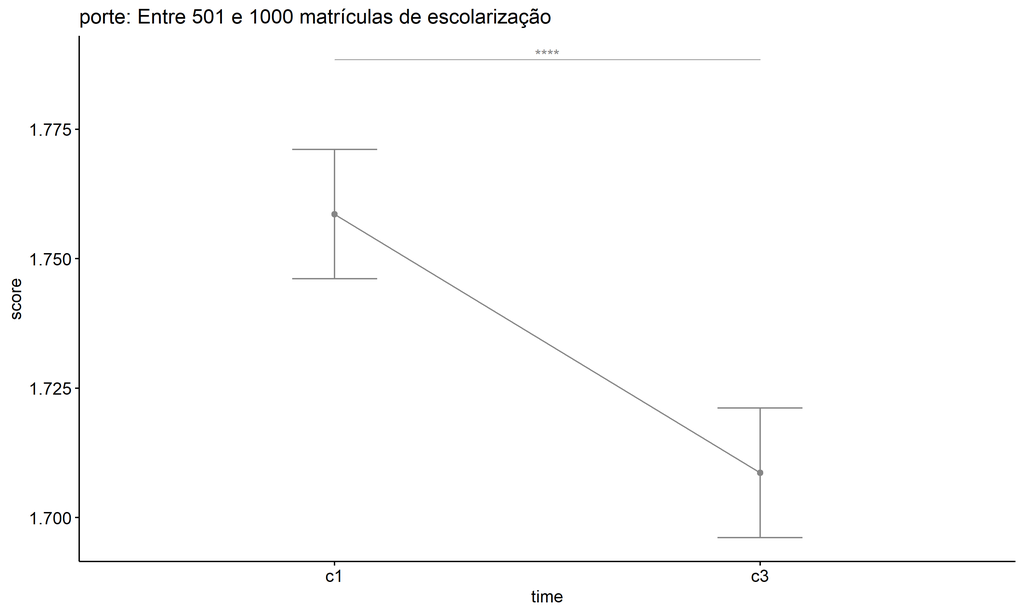

```r
emms.gg <- emms[which(emms$porte == "Entre 501 e 1000 matrículas de escolarização"),]
if (nrow(emms.gg) > 0)
  ggline(emms.gg, x = "time", y = "emmean", color = "#868686FF", ylab = "score") +
    geom_errorbar(aes(ymin = conf.low, ymax = conf.high),
                  width = 0.2, color = "#868686FF") +
    stat_pvalue_manual(
      add_xy_position(pwc[which(pwc$porte == "Entre 501 e 1000 matrículas de escolarização"),],
                      x = "time", fun = "mean_se"),
      hide.ns = T, color = "#868686FF", tip.length = F) +
    labs(title = "porte: Entre 501 e 1000 matrículas de escolarização")+
    theme(legend.text = element_blank())
```

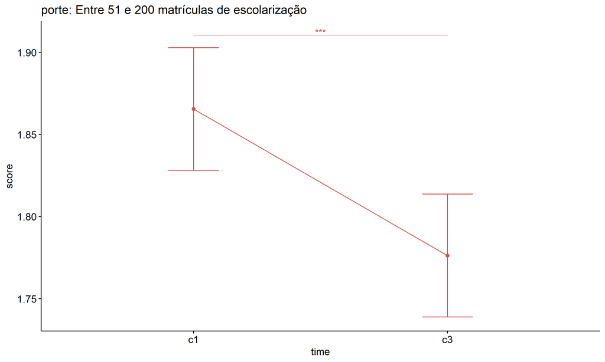

```r
emms.gg <- emms[which(emms$porte == "Entre 51 e 200 matrículas de escolarização"),]
if (nrow(emms.gg) > 0)
  ggline(emms.gg, x = "time", y = "emmean", color = "#CD534CFF", ylab = "score") +
    geom_errorbar(aes(ymin = conf.low, ymax = conf.high),
                  width = 0.2, color = "#CD534CFF") +
    stat_pvalue_manual(
      add_xy_position(pwc[which(pwc$porte == "Entre 51 e 200 matrículas de escolarização"),],
                      x = "time", fun = "mean_se"),
      hide.ns = T, color = "#CD534CFF", tip.length = F) +
    labs(title = "porte: Entre 51 e 200 matrículas de escolarização")+
    theme(legend.text = element_blank())
```

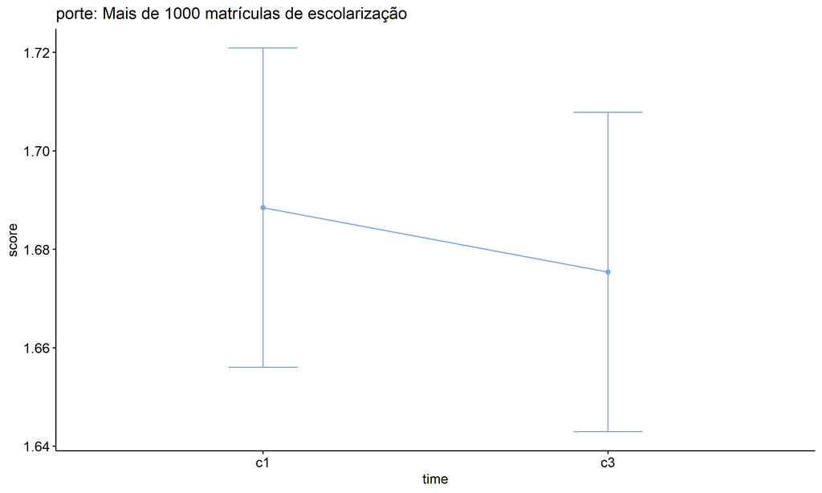

```r
emms.gg <- emms[which(emms$porte == "Mais de 1000 matrículas de escolarização"),]
if (nrow(emms.gg) > 0)
  ggline(emms.gg, x = "time", y = "emmean", color = "#7AA6DCFF", ylab = "score") +
    geom_errorbar(aes(ymin = conf.low, ymax = conf.high),
                  width = 0.2, color = "#7AA6DCFF") +
    stat_pvalue_manual(
      add_xy_position(pwc[which(pwc$porte == "Mais de 1000 matrículas de escolarização"),],
                      x = "time", fun = "mean_se"),
      hide.ns = T, color = "#7AA6DCFF", tip.length = F) +
    labs(title = "porte: Mais de 1000 matrículas de escolarização")+
    theme(legend.text = element_blank())
```

## PairWise Computation after removing non.normal data

```r
if (length(non.ids) > 0)
  (pwc2 <- ldat2 %>% group_by(time) %>%
     emmeans_test(score ~ porte, detailed = T, p.adjust.method = "bonferroni"))
```

```r
if (length(non.ids) > 0)
  (emms2 <- get_emmeans(pwc2))
```

```r
if (length(non.ids) > 0) {
  pwc2 <- add_xy_position(pwc2, x = "time", fun = "mean_se", dodge = 0.25)
  pd2 <- position_dodge(width = 0.25)

  ggline(emms2, x = "time", y = "emmean", color = "porte",
         palette = c("#0073C2FF","#EFC000FF","#868686FF","#CD534CFF","#7AA6DCFF"),
         position = pd, ylab = "score") +
    geom_errorbar(aes(ymin = conf.low, ymax = conf.high, color = porte),
                position = pd, width = 0.2) +
    stat_pvalue_manual(pwc2, hide.ns = T, tip.length = F, linetype = 1)
}
```

```r
if (length(non.ids) > 0)
  (pwc2 <- ldat2 %>% group_by(porte) %>%
     emmeans_test(score ~ time, detailed = T, p.adjust.method = "bonferroni"))
```

```r
if (length(non.ids) > 0)
  (emms2 <- get_emmeans(pwc2))
```

```r
if (length(non.ids) > 0) {
  emms.gg <- emms2[which(emms2$porte == "Até 50 matrículas de escolarização"),]
  if (nrow(emms.gg) > 0)
    ggline(emms.gg, x = "time", y = "emmean", color = "#0073C2FF", ylab = "score") +
    geom_errorbar(aes(ymin = conf.low, ymax = conf.high),
                  width = 0.2, color = "#0073C2FF") +
    stat_pvalue_manual(
      add_xy_position(pwc[which(pwc$porte == "Até 50 matrículas de escolarização"),],
                      x = "time", fun = "mean_se"),
      hide.ns = T, color = "#0073C2FF", tip.length = F) +
    labs(title = "porte: Até 50 matrículas de escolarização") +
    theme(legend.text = element_blank())
}
```

```r
if (length(non.ids) > 0) {
  emms.gg <- emms2[which(emms2$porte == "Entre 201 e 500 matrículas de escolarização"),]
  if (nrow(emms.gg) > 0)
    ggline(emms.gg, x = "time", y = "emmean", color = "#EFC000FF", ylab = "score") +
    geom_errorbar(aes(ymin = conf.low, ymax = conf.high),
                  width = 0.2, color = "#EFC000FF") +
    stat_pvalue_manual(
      add_xy_position(pwc[which(pwc$porte == "Entre 201 e 500 matrículas de escolarização"),],
                      x = "time", fun = "mean_se"),
      hide.ns = T, color = "#EFC000FF", tip.length = F) +
    labs(title = "porte: Entre 201 e 500 matrículas de escolarização") +
    theme(legend.text = element_blank())
}
```

```r
if (length(non.ids) > 0) {
  emms.gg <- emms2[which(emms2$porte == "Entre 501 e 1000 matrículas de escolarização"),]
  if (nrow(emms.gg) > 0)
    ggline(emms.gg, x = "time", y = "emmean", color = "#868686FF", ylab = "score") +
    geom_errorbar(aes(ymin = conf.low, ymax = conf.high),
                  width = 0.2, color = "#868686FF") +
    stat_pvalue_manual(
      add_xy_position(pwc[which(pwc$porte == "Entre 501 e 1000 matrículas de escolarização"),],
                      x = "time", fun = "mean_se"),
      hide.ns = T, color = "#868686FF", tip.length = F) +
    labs(title = "porte: Entre 501 e 1000 matrículas de escolarização") +
    theme(legend.text = element_blank())
}
```

```r
if (length(non.ids) > 0) {
  emms.gg <- emms2[which(emms2$porte == "Entre 51 e 200 matrículas de escolarização"),]
  if (nrow(emms.gg) > 0)
    ggline(emms.gg, x = "time", y = "emmean", color = "#CD534CFF", ylab = "score") +
    geom_errorbar(aes(ymin = conf.low, ymax = conf.high),
                  width = 0.2, color = "#CD534CFF") +
    stat_pvalue_manual(
      add_xy_position(pwc[which(pwc$porte == "Entre 51 e 200 matrículas de escolarização"),],
                      x = "time", fun = "mean_se"),
      hide.ns = T, color = "#CD534CFF", tip.length = F) +
    labs(title = "porte: Entre 51 e 200 matrículas de escolarização") +
    theme(legend.text = element_blank())
}
```

```r
if (length(non.ids) > 0) {
  emms.gg <- emms2[which(emms2$porte == "Mais de 1000 matrículas de escolarização"),]
  if (nrow(emms.gg) > 0)
    ggline(emms.gg, x = "time", y = "emmean", color = "#7AA6DCFF", ylab = "score") +
    geom_errorbar(aes(ymin = conf.low, ymax = conf.high),
                  width = 0.2, color = "#7AA6DCFF") +
    stat_pvalue_manual(
      add_xy_position(pwc[which(pwc$porte == "Mais de 1000 matrículas de escolarização"),],
                      x = "time", fun = "mean_se"),
      hide.ns = T, color = "#7AA6DCFF", tip.length = F) +
    labs(title = "porte: Mais de 1000 matrículas de escolarização") +
    theme(legend.text = element_blank())
}
```